# Survey Analysis

Mohammad Ali Momen

05/01/2023

**Data Analysis methodology**: CRISP-DM

**Dataset**: Customer survey of an USA paper company

**Case Goal**: Which variables affect on business income variables?

# 1 Required Libraries

```r
library(moments)
library(MASS)
library(mice)
```

# 2 Read Data from File

```r
data <- read.csv('CS_01_01.csv', header = T)
dim(data)  # 200 records, 24 variables
```

```
## [1] 200  24
```

```r
# Second version of above dataset with Missing-Values
data_mv <- read.csv('CS_01_02.csv', header = T)
dim(data_mv)  # 70 records, 15 varibles
```

```
## [1] 70 15
```

# 3 Business Understanding

- know business process and issues
- know the context of the problem
- know the order of numbers in the business

# 4 Data Understanding

## 4.1 Data Inspection

Data Understanding from Free Perspective

### 4.1.1 Dataset variables definition

```r
colnames(data)
```

```
##  [1] "ID"                    "customer_type"         "industry_type"
##  [4] "firm_size"             "region"                "dist_system"
##  [7] "prod_quality"          "e_commerce"            "tech_support"
## [10] "complaint_resolution"  "advertising"           "prod_line"
## [13] "salesforce_image"      "competitive_pricing"   "warranty"
## [16] "new_products"          "ordering_billing"      "price_flexibility"
## [19] "delivery_speed"        "customer_satisfaction" "likelihood_recom"
## [22] "likelihood_purchase"   "percentage_purchase"   "future_relationship"
```

> Demographics variables (controlling variables)
- **customer_type**: Length of time a particular customer has been buying from company:
  - 1 = less than 1 year
  - 2 = between 1 and 5 years
  - 3 = longer than 5 years
- **industry_type**: Type of industry that purchases paper products:
  - 0 = magazine industry
  - 1 = newsprint industry
- **firm_size**: Employee (organization) size:
  - 0 = small firm, fewer than 500 employees
  - 1 = large firm, 500 or more employees
- **region**: Customer location:
  - 0 = USA/North America
  - 1 = outside North America
- **dist_system**: How paper products are sold to customers (distribution system):
  - 0 = sold indirectly through a broker
  - 1 = sold directly

> Perception of the company (predictor variables)
- **prod_quality**: Perceived level of quality of the company’s paper products (product quality)
- **e_commerce**: Overall image of HBAT’s Web site, especially user-friendliness (online platform)
- **tech_support**: Extent to which technical support is offered to help solve product/service issues
- **complaint_resolution**: Extent to which any complaints are resolved in a timely and complete manner
- **advertising**: Perceptions of the company’s advertising campaigns in all types of media
- **prod_line**: Depth and breadth of company’s product line to meet customer needs
- **salesforce_image**: Overall image of company’s salesforce
- **competitive_pricing**: Extent to which the company offers competitive prices
- **warranty**: Extent to which the company stands behind its product/service warranties and claims
- **new_products**: Extent to which the company develops and sells new products
- **ordering_billing**: Perception that ordering and billing is handled efficiently and correctly
- **price_flexibility**: Perceived willingness of the company sales reps to negotiate price on purchases of paper products
- **delivery_speed**: Amount of time it takes to deliver the paper products once an order has been confirm

> Purchase outcome section (target variables)
- **customer_satisfaction**: Customer satisfaction with past purchases from the company, measured on a 10-point graphic rating scale
- **likelihood_recom**: Likelihood of recommending the company to other firms as a supplier of paper products, measured on a 10-point graphic rating scale
- **likelihood_purchase**: Likelihood of purchasing paper products from the company in the future, measured on a 10-point graphic rating scale
- **percentage_purchase**: Percentage of the responding firm’s paper needs purchased from the company, measured on a 100-point percentage scale
- **future_relationship**: Extent to which the customer/respondent perceives his or her firm would engage in strategic alliance/partnership with the company:
  - 0 = Would not consider
  - 1 = Yes, would consider strategic alliance or partnership

## 4.2 Data Exploring

Data Understanding from Statistical Perspective

### 4.2.1 Overview of Dataframe

```r
class(data)
```

```
## [1] "data.frame"
```

```r
dim(data)
```

```
## [1] 200  24
```

```r
head(data)
```

|  | ID | customer_type | industry_type | firm_size | region | dist_system | prod_quality | e_commerce | tech_support | complaint_resolution | advertising | prod_line | salesforce_image | competitive_pricing | warranty | new_products | ordering_billing | price_flexibility | delivery_speed | customer_satisfaction | likelihood_recom | likelihood_purchase | percentage_purchase | future_relationship |
| --- | --- | --- | --- | --- | --- | --- | --- | --- | --- | --- | --- | --- | --- | --- | --- | --- | --- | --- | --- | --- | --- | --- | --- | --- |
| 1 | 1 | 2 | 0 | 1 | 1 | 1 | 8.5 | 3.9 | 2.5 | 5.9 | 4.8 | 4.9 | 6.0 | 6.8 | 4.7 | 4.3 | 5.0 | 5.1 | 3.7 | 8.2 | 8.0 | 8.4 | 65.1 | 1 |
| 2 | 2 | 3 | 1 | 0 | 0 | 0 | 8.2 | 2.7 | 5.1 | 7.2 | 3.4 | 7.9 | 3.1 | 5.3 | 5.5 | 4.0 | 3.9 | 4.3 | 4.9 | 5.7 | 6.5 | 7.5 | 67.1 | 0 |
| 3 | 3 | 3 | 0 | 1 | 1 | 1 | 9.2 | 3.4 | 5.6 | 5.6 | 5.4 | 7.4 | 5.8 | 4.5 | 6.2 | 4.6 | 5.4 | 4.0 | 4.5 | 8.9 | 8.4 | 9.0 | 72.1 | 1 |
| 4 | 4 | 1 | 1 | 1 | 1 | 0 | 6.4 | 3.3 | 7.0 | 3.7 | 4.7 | 4.7 | 4.5 | 8.8 | 7.0 | 3.6 | 4.3 | 4.1 | 3.0 | 4.8 | 6.0 | 7.2 | 40.1 | 0 |
| 5 | 5 | 2 | 0 | 1 | 0 | 1 | 9.0 | 3.4 | 5.2 | 4.6 | 2.2 | 6.0 | 4.5 | 6.8 | 6.1 | 4.5 | 4.5 | 3.5 | 3.5 | 7.1 | 6.6 | 9.0 | 57.1 | 0 |
| 6 | 6 | 1 | 1 | 0 | 1 | 0 | 6.5 | 2.8 | 3.1 | 4.1 | 4.0 | 4.3 | 3.7 | 8.5 | 5.1 | 9.5 | 3.6 | 4.7 | 3.3 | 4.7 | 6.3 | 6.1 | 50.1 | 0 |

```r
tail(data)
```

|  | ID | customer_type | industry_type | firm_size | region | dist_system | prod_quality | e_commerce | tech_support | complaint_resolution | advertising | prod_line | salesforce_image | competitive_pricing | warranty | new_products | ordering_billing | price_flexibility | delivery_speed | customer_satisfaction | likelihood_recom | likelihood_purchase | percentage_purchase | future_relationship |
| --- | --- | --- | --- | --- | --- | --- | --- | --- | --- | --- | --- | --- | --- | --- | --- | --- | --- | --- | --- | --- | --- | --- | --- | --- |
| 195 | 195 | 1 | 1 | 0 | 1 | 0 | 6.4 | 3.3 | 2.7 | 4.0 | 5.3 | 4.7 | 4.5 | 8.8 | 3.7 | 7.0 | 3.6 | 4.1 | 3.0 | 4.8 | 5.5 | 6.0 | 40.1 | 0 |
| 196 | 196 | 3 | 1 | 1 | 0 | 0 | 7.6 | 3.6 | 2.1 | 5.2 | 4.8 | 6.6 | 5.4 | 4.4 | 4.3 | 6.8 | 4.4 | 3.9 | 4.0 | 8.2 | 6.9 | 8.4 | 58.1 | 1 |
| 197 | 197 | 2 | 1 | 1 | 1 | 0 | 5.9 | 4.0 | 3.3 | 7.8 | 3.3 | 5.9 | 6.2 | 8.4 | 5.2 | 6.6 | 6.0 | 7.5 | 5.4 | 7.9 | 7.8 | 8.6 | 62.1 | 1 |
| 198 | 198 | 3 | 1 | 1 | 1 | 1 | 9.7 | 5.0 | 7.9 | 6.3 | 5.3 | 7.6 | 6.1 | 6.8 | 6.6 | 5.2 | 4.4 | 3.5 | 4.2 | 8.6 | 8.8 | 7.9 | 66.1 | 1 |
| 199 | 199 | 2 | 1 | 1 | 1 | 1 | 5.5 | 5.5 | 6.9 | 6.6 | 6.5 | 5.7 | 8.2 | 6.3 | 7.0 | 5.3 | 5.9 | 6.7 | 4.9 | 8.2 | 7.1 | 7.6 | 59.1 | 1 |
| 200 | 200 | 3 | 1 | 0 | 1 | 1 | 9.7 | 5.0 | 5.6 | 5.9 | 5.3 | 7.6 | 6.1 | 6.8 | 6.9 | 1.2 | 4.3 | 3.5 | 4.2 | 8.6 | 8.1 | 8.5 | 66.1 | 1 |

```r
data
```

[output not shown]

[output cut: 190 more lines]

```r
str(data)
```

```
## 'data.frame':    200 obs. of  24 variables:
##  $ ID                   : int  1 2 3 4 5 6 7 8 9 10 ...
##  $ customer_type        : int  2 3 3 1 2 1 1 2 2 1 ...
##  $ industry_type        : int  0 1 0 1 0 1 1 0 1 0 ...
##  $ firm_size            : int  1 0 1 1 1 0 1 1 1 1 ...
##  $ region               : int  1 0 1 1 0 1 1 1 1 1 ...
##  $ dist_system          : int  1 0 1 0 1 0 0 0 0 0 ...
##  $ prod_quality         : num  8.5 8.2 9.2 6.4 9 6.5 6.9 6.2 5.8 6.4 ...
##  $ e_commerce           : num  3.9 2.7 3.4 3.3 3.4 2.8 3.7 3.3 3.6 4.5 ...
##  $ tech_support         : num  2.5 5.1 5.6 7 5.2 3.1 5 3.9 5.1 5.1 ...
##  $ complaint_resolution : num  5.9 7.2 5.6 3.7 4.6 4.1 2.6 4.8 6.7 6.1 ...
##  $ advertising          : num  4.8 3.4 5.4 4.7 2.2 4 2.1 4.6 3.7 4.7 ...
##  $ prod_line            : num  4.9 7.9 7.4 4.7 6 4.3 2.3 3.6 5.9 5.7 ...
##  $ salesforce_image     : num  6 3.1 5.8 4.5 4.5 3.7 5.4 5.1 5.8 5.7 ...
##  $ competitive_pricing  : num  6.8 5.3 4.5 8.8 6.8 8.5 8.9 6.9 9.3 8.4 ...
##  $ warranty             : num  4.7 5.5 6.2 7 6.1 5.1 4.8 5.4 5.9 5.4 ...
##  $ new_products         : num  4.3 4 4.6 3.6 4.5 9.5 2.5 4.8 4.4 5.3 ...
##  $ ordering_billing     : num  5 3.9 5.4 4.3 4.5 3.6 2.1 4.3 4.4 4.1 ...
##  $ price_flexibility    : num  5.1 4.3 4 4.1 3.5 4.7 4.2 6.3 6.1 5.8 ...
##  $ delivery_speed       : num  3.7 4.9 4.5 3 3.5 3.3 2 3.7 4.6 4.4 ...
##  $ customer_satisfaction: num  8.2 5.7 8.9 4.8 7.1 4.7 5.7 6.3 7 5.5 ...
##  $ likelihood_recom     : num  8 6.5 8.4 6 6.6 6.3 7.8 5.8 7.5 5.9 ...
##  $ likelihood_purchase  : num  8.4 7.5 9 7.2 9 6.1 7.2 7.7 8.2 6.7 ...
##  $ percentage_purchase  : num  65.1 67.1 72.1 40.1 57.1 50.1 41.1 56.1 56.1 59.1 ...
##  $ future_relationship  : int  1 0 1 0 0 0 0 0 1 0 ...
```

### 4.2.2 Categorical variables should be stored as factor

```r
data$customer_type <- factor(data$customer_type)
data$industry_type <- factor(data$industry_type)
data$firm_size <- factor(data$firm_size)
data$region <- factor(data$region)
data$dist_system <- factor(data$dist_system)
data$future_relationship <- factor(data$future_relationship)

summary(data)
```

```
##        ID         customer_type industry_type firm_size region  dist_system
##  Min.   :  1.00   1:68          0:100         0: 98     0: 81   0:108
##  1st Qu.: 50.75   2:64          1:100         1:102     1:119   1: 92
##  Median :100.50   3:68
##  Mean   :100.50
##  3rd Qu.:150.25
##  Max.   :200.00
##   prod_quality      e_commerce     tech_support   complaint_resolution
##  Min.   : 5.000   Min.   :2.200   Min.   :0.400   Min.   :1.500
##  1st Qu.: 6.700   1st Qu.:3.300   1st Qu.:4.100   1st Qu.:4.500
##  Median : 8.050   Median :3.700   Median :5.300   Median :5.400
##  Mean   : 7.894   Mean   :3.765   Mean   :5.243   Mean   :5.367
##  3rd Qu.: 9.100   3rd Qu.:4.100   3rd Qu.:6.425   3rd Qu.:6.200
##  Max.   :10.000   Max.   :5.700   Max.   :8.900   Max.   :8.700
##   advertising      prod_line     salesforce_image competitive_pricing
##  Min.   :1.500   Min.   :2.300   Min.   :2.500    Min.   : 3.700
##  1st Qu.:3.200   1st Qu.:4.800   1st Qu.:4.575    1st Qu.: 5.800
##  Median :4.000   Median :5.700   Median :5.000    Median : 7.150
##  Mean   :4.061   Mean   :5.815   Mean   :5.248    Mean   : 6.971
##  3rd Qu.:4.925   3rd Qu.:6.900   3rd Qu.:6.000    3rd Qu.: 8.325
##  Max.   :6.900   Max.   :8.400   Max.   :8.200    Max.   :10.000
##     warranty      new_products   ordering_billing price_flexibility
##  Min.   :3.700   Min.   :1.200   Min.   :1.200    Min.   :2.300
##  1st Qu.:5.400   1st Qu.:4.200   1st Qu.:3.700    1st Qu.:3.575
##  Median :6.100   Median :5.200   Median :4.300    Median :4.250
##  Mean   :6.048   Mean   :5.210   Mean   :4.242    Mean   :4.464
##  3rd Qu.:6.600   3rd Qu.:6.225   3rd Qu.:4.700    3rd Qu.:5.325
##  Max.   :8.400   Max.   :9.500   Max.   :6.700    Max.   :7.500
##  delivery_speed  customer_satisfaction likelihood_recom likelihood_purchase
##  Min.   :1.600   Min.   :4.700         Min.   :4.000    Min.   :4.300
##  1st Qu.:3.300   1st Qu.:6.000         1st Qu.:6.100    1st Qu.:7.100
##  Median :3.900   Median :7.050         Median :7.000    Median :7.600
##  Mean   :3.816   Mean   :6.952         Mean   :6.952    Mean   :7.665
##  3rd Qu.:4.325   3rd Qu.:7.900         3rd Qu.:7.650    3rd Qu.:8.200
##  Max.   :5.500   Max.   :9.900         Max.   :9.900    Max.   :9.900
##  percentage_purchase future_relationship
##  Min.   :37.10       0:114
##  1st Qu.:51.10       1: 86
##  Median :58.60
##  Mean   :58.20
##  3rd Qu.:65.35
##  Max.   :77.10
```

### 4.2.3 Univariate Profiling

check each variable individually

#### 4.2.3.1 Categorical variables

customer_type

```r
summary(data$customer_type)
```

```
##  1  2  3
## 68 64 68
```

```r
table(data$customer_type, useNA = 'ifany')
```

```
##
##  1  2  3
## 68 64 68
```

```r
sum(is.na(data$customer_type))
```

```
## [1] 0
```

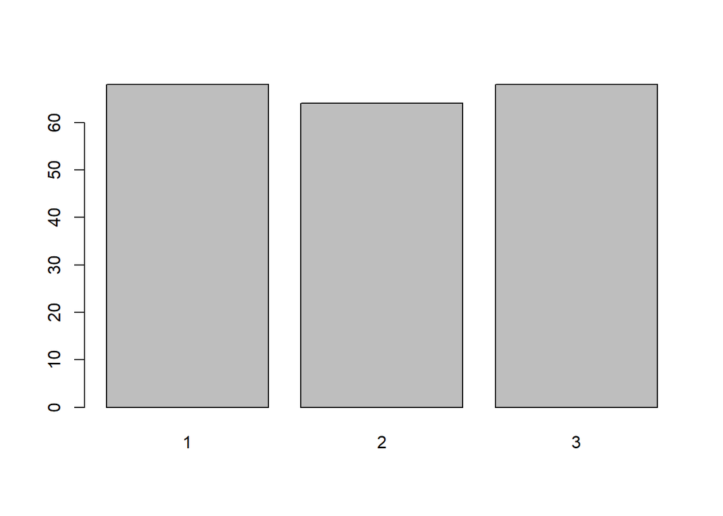

```r
barplot(table(data$customer_type))
```

industry_type

```r
summary(data$industry_type)
```

```
##   0   1
## 100 100
```

```r
table(data$industry_type, useNA = 'ifany')
```

```
##
##   0   1
## 100 100
```

```r
sum(is.na(data$industry_type))
```

```
## [1] 0
```

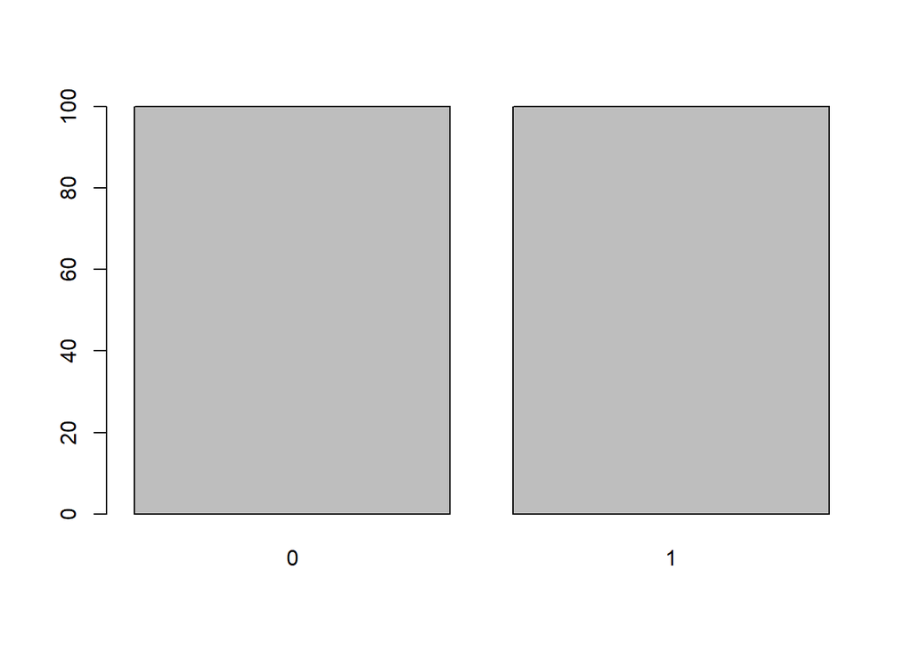

```r
barplot(table(data$industry_type))
```

#### 4.2.3.2 Continuous variables

ID

```r
length(unique(data$ID)) == nrow(data)  # check ID uniqueness
```

```
## [1] TRUE
```

```r
rownames(data) <- data$ID
data <- data[,-1]
```

prod_quality

```r
summary(data$prod_quality)
```

```
##    Min. 1st Qu.  Median    Mean 3rd Qu.    Max.
##   5.000   6.700   8.050   7.894   9.100  10.000
```

```r
range(data$prod_quality)
```

```
## [1]  5 10
```

```r
quantile(data$prod_quality)
```

```
##    0%   25%   50%   75%  100%
##  5.00  6.70  8.05  9.10 10.00
```

```r
sum(is.na(data$prod_quality))  # missing value
```

```
## [1] 0
```

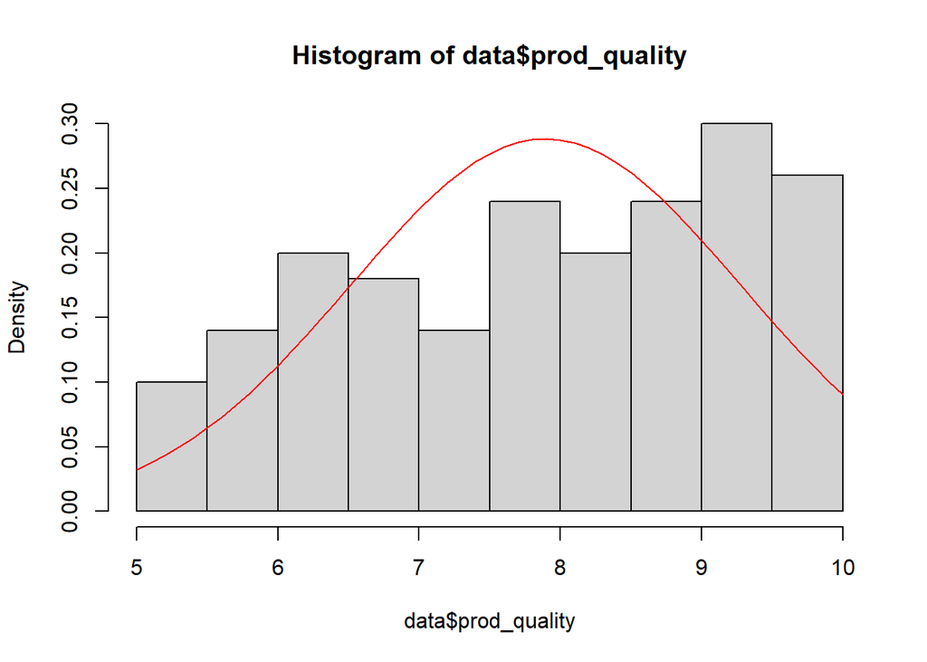

```r
hist(data$prod_quality, freq=F)  # distribution
x_fit <- seq(min(data$prod_quality), max(data$prod_quality), by=0.1)
y_fit <- dnorm(x_fit, mean=mean(data$prod_quality), sd=sd(data$prod_quality))
lines(x_fit, y_fit, col='red')  # draw a normal distribution density curve with same mean and sd to data
```

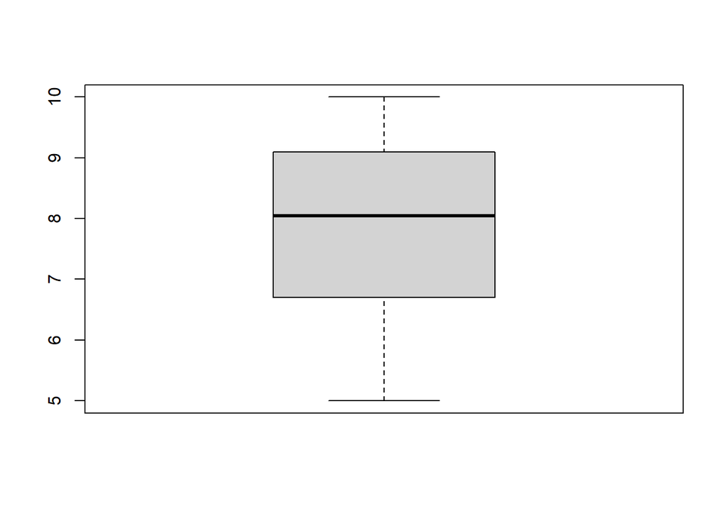

```r
boxplot(data$prod_quality)  # outliers detection by Tukey method
```

Test of distribution Normality

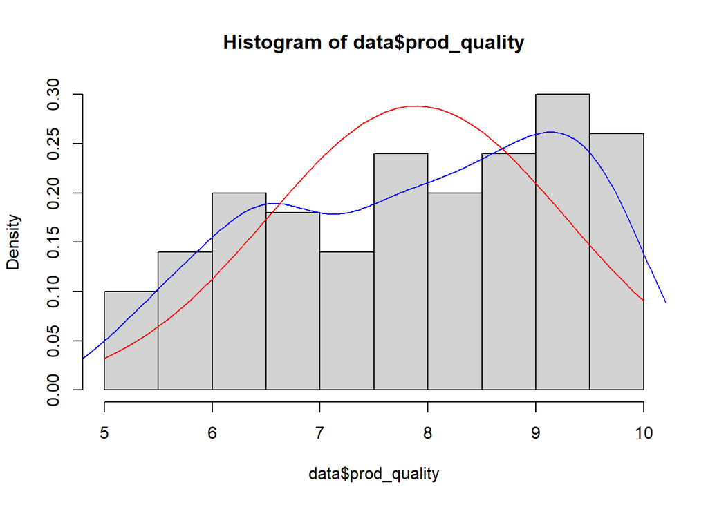

```r
hist(data$prod_quality, freq=F, breaks=15)
lines(density(data$prod_quality), col='blue')
x_fit <- seq(min(data$prod_quality), max(data$prod_quality), by=0.1)
y_fit <- dnorm(x_fit, mean=mean(data$prod_quality), sd=sd(data$prod_quality))
lines(x_fit, y_fit, col='red')
```

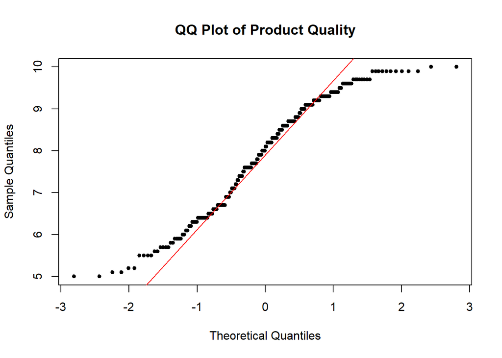

```r
qqnorm(data$prod_quality, main='QQ Plot of Product Quality', pch=20)
qqline(data$prod_quality, col='red')
```

```r
# Normality test
#H0 (Null) assumption: data is from normal distribution
#H1 (Alternative) assumption: data is not from normal distribution
#p-value < 0.05 reject normality assumption (reject H0)
shapiro.test(data$prod_quality)
```

```
##
##  Shapiro-Wilk normality test
##
## data:  data$prod_quality
## W = 0.94985, p-value = 1.824e-06
```

```r
# Skewness test
#H0 (Null) assumption: sample skewness is equal to 0
#H1 (Alternative) assumption: sample skewness is not equal to 0
#p-value < 0.05 reject normality assumption
jarque.test(data$prod_quality)
```

```
##
##  Jarque-Bera Normality Test
##
## data:  data$prod_quality
## JB = 12.414, p-value = 0.002015
## alternative hypothesis: greater
```

```r
# Kurtosis test
#H0 (Null) assumption: sample kurtosis is equal to 3 (normal distribution kurtosis)
#H1 (Alternative) assumption: sample kurtosis is not equal to 3
#p-value < 0.05 reject normality assumption
anscombe.test(data$prod_quality)
```

```
##
##  Anscombe-Glynn kurtosis test
##
## data:  data$prod_quality
## kurt = 1.9204, z = -7.0312, p-value = 2.048e-12
## alternative hypothesis: kurtosis is not equal to 3
```

> **Conclusion**: reject normality assumption

e_commerce

```r
summary(data$e_commerce)
```

```
##    Min. 1st Qu.  Median    Mean 3rd Qu.    Max.
##   2.200   3.300   3.700   3.765   4.100   5.700
```

```r
range(data$e_commerce)
```

```
## [1] 2.2 5.7
```

```r
quantile(data$e_commerce)
```

```
##   0%  25%  50%  75% 100%
##  2.2  3.3  3.7  4.1  5.7
```

```r
sum(is.na(data$e_commerce))  # missing value
```

```
## [1] 0
```

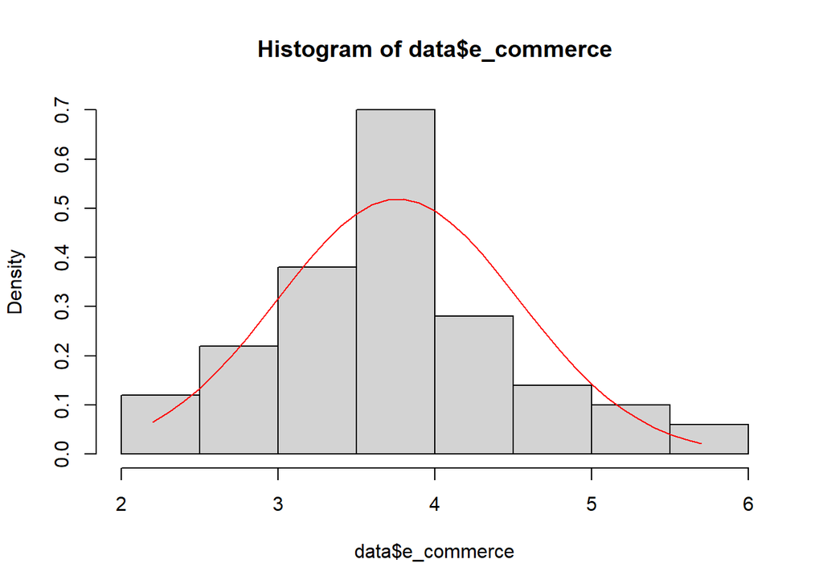

```r
hist(data$e_commerce, freq=F)  # distribution
x_fit <- seq(min(data$e_commerce), max(data$e_commerce), by=0.1)
y_fit <- dnorm(x_fit, mean=mean(data$e_commerce), sd=sd(data$e_commerce))
lines(x_fit, y_fit, col='red')  # draw a normal distribution density curve with same mean and sd to data
```

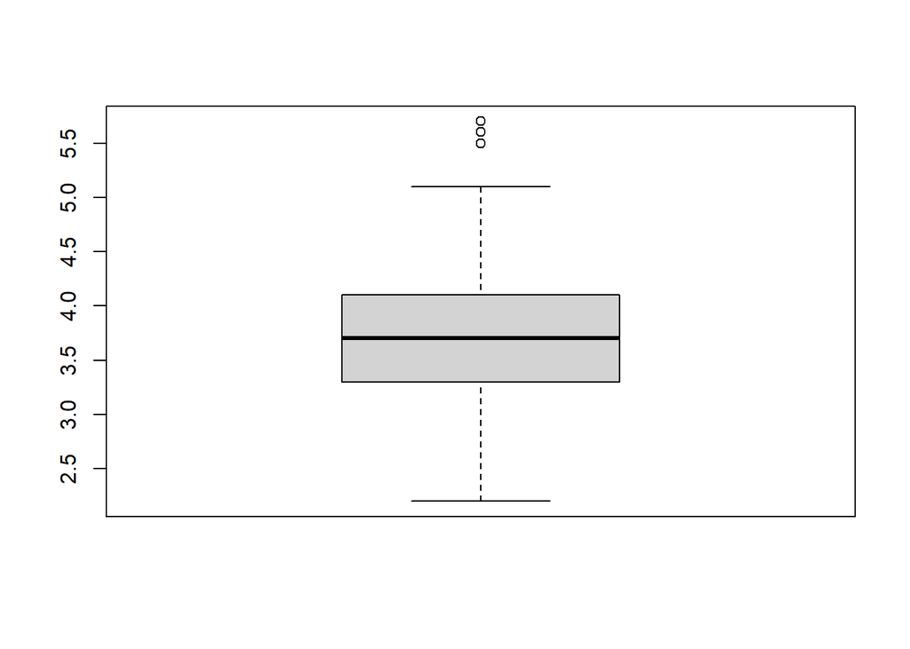

```r
boxplot(data$e_commerce)  # outliers detection by Tukey method
```

Test of distribution Normality

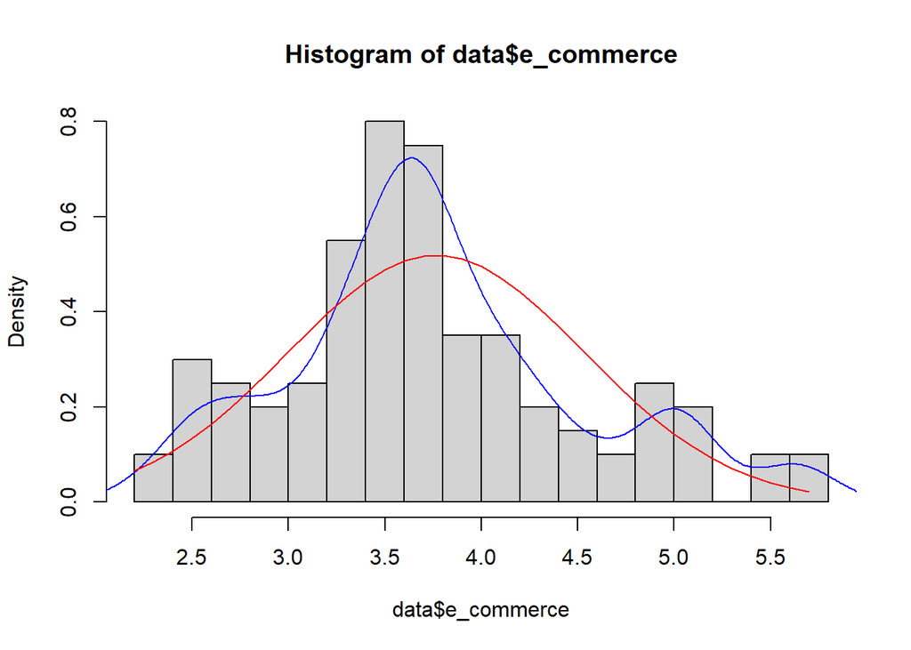

```r
hist(data$e_commerce, freq=F, breaks=15)
lines(density(data$e_commerce), col='blue')
x_fit <- seq(min(data$e_commerce), max(data$e_commerce), by=0.1)
y_fit <- dnorm(x_fit, mean=mean(data$e_commerce), sd=sd(data$e_commerce))
lines(x_fit, y_fit, col='red')
```

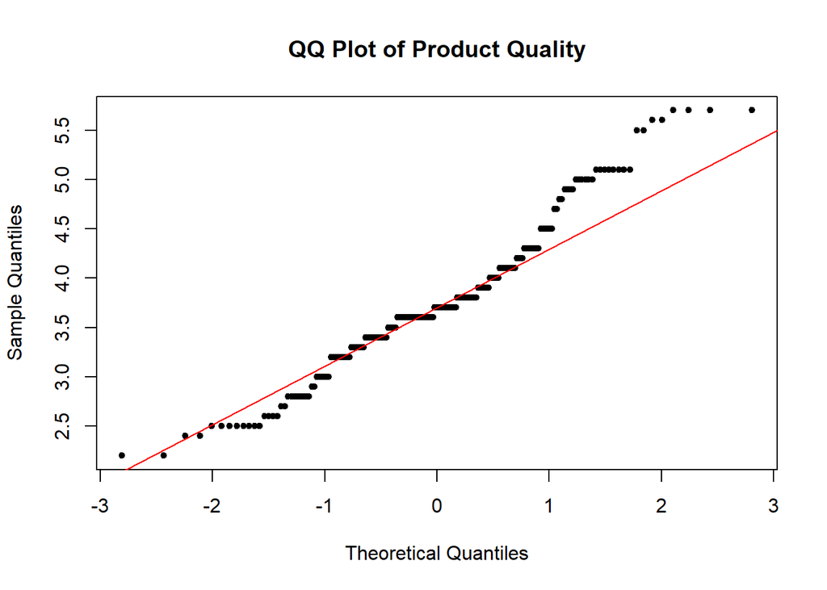

```r
qqnorm(data$e_commerce, main='QQ Plot of Product Quality', pch=20)
qqline(data$e_commerce, col='red')
```

```r
# Normality test
#H0 (Null) assumption: data is from normal distribution
#H1 (Alternative) assumption: data is not from normal distribution
#p-value < 0.05 reject normality assumption (reject H0)
shapiro.test(data$e_commerce)
```

```
##
##  Shapiro-Wilk normality test
##
## data:  data$e_commerce
## W = 0.96247, p-value = 3.691e-05
```

```r
# Skewness test
#H0 (Null) assumption: sample skewness is equal to 0
#H1 (Alternative) assumption: sample skewness is not equal to 0
#p-value < 0.05 reject normality assumption
jarque.test(data$e_commerce)
```

```
##
##  Jarque-Bera Normality Test
##
## data:  data$e_commerce
## JB = 7.8866, p-value = 0.01938
## alternative hypothesis: greater
```

```r
# Kurtosis test
#H0 (Null) assumption: sample kurtosis is equal to 3 (normal distribution kurtosis)
#H1 (Alternative) assumption: sample kurtosis is not equal to 3
#p-value < 0.05 reject normality assumption
anscombe.test(data$e_commerce)
```

```
##
##  Anscombe-Glynn kurtosis test
##
## data:  data$e_commerce
## kurt = 3.04237, z = 0.36564, p-value = 0.7146
## alternative hypothesis: kurtosis is not equal to 3
```

> **Conclusion**: reject normality assumption

#### 4.2.3.3 Plot all 13 measuring perception variables in one plot

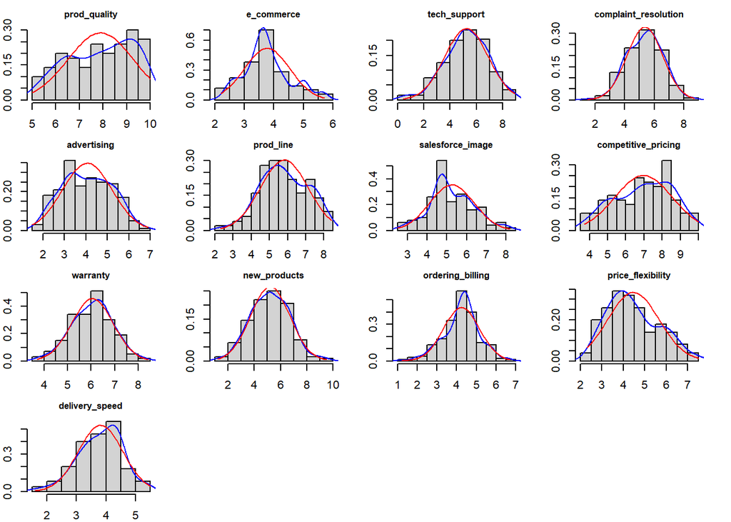

```r
par(mfrow = c(4,4), mar = c(2,2,2,2), cex.main = 0.8)
for(i in 6:18){
    hist(data[,i],
        xlab = "",
        main = colnames(data)[i],
        freq = F)

    lines(density(data[,i]), col = 'blue')

    x_fit <- seq(min(data[,i]), max(data[,i]), length.out = 50)
    y_fit <- dnorm(x_fit, mean = mean(data[,i]), sd = sd(data[,i]))
    lines(x_fit, y_fit, col = 'red')
}

par(mfrow = c(1,1), mar = c(5, 4, 4, 2) + 0.1, cex.main = 1)
```

### 4.2.4 Bivariate Profiling

measure 2-2 relationships between variables

#### 4.2.4.1 Two Continuous variables (Correlation Analysis)

```r
cor(data$prod_quality, data$likelihood_purchase, method = 'pearson')
```

```
## [1] 0.4333715
```

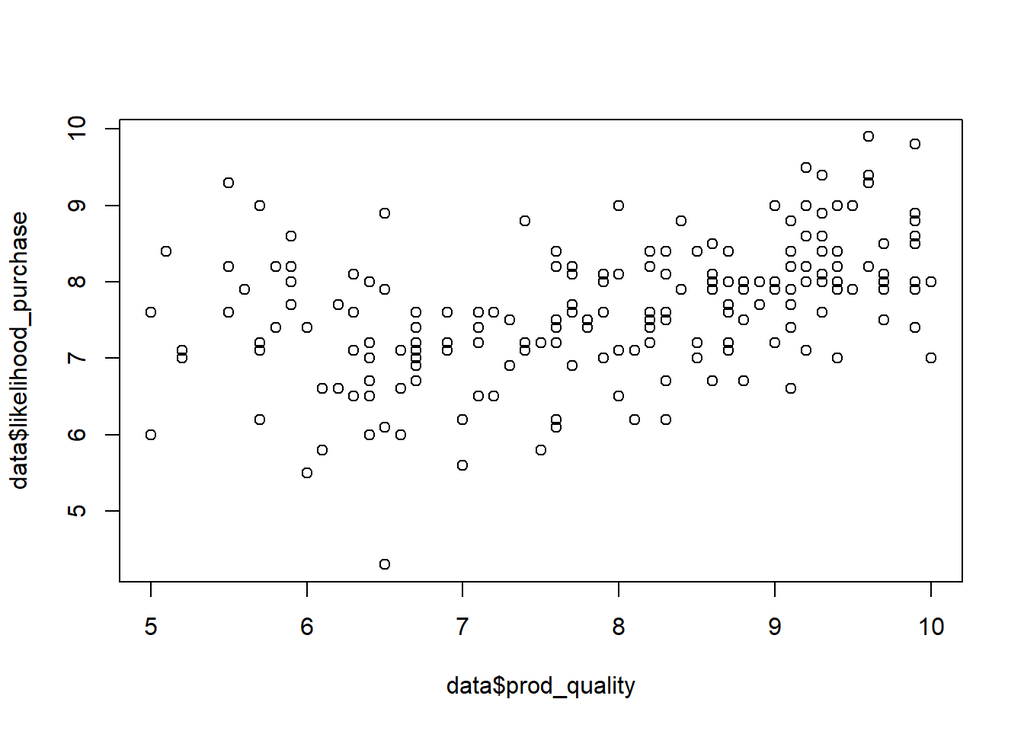

```r
plot(data$prod_quality, data$likelihood_purchase)
```

Hypothesis Test: Spearman Correlation test

```r
#H0(Null hypothesis): cor = 0 in population
#H1(Alternative hypothesis): cor in population is not 0 and is = what we calculated for cor based-on our statistical sample
#p-value < 0.05 reject H0 assumption
cor.test(data$prod_quality, data$likelihood_purchase, method = 'spearman', exact = F)
```

```
##
##  Spearman's rank correlation rho
##
## data:  data$prod_quality and data$likelihood_purchase
## S = 735626, p-value = 2.809e-11
## alternative hypothesis: true rho is not equal to 0
## sample estimates:
##       rho
## 0.4482665
```

Correlation table

```r
cor_table <- round(cor(data[,c(21, 6:18)]), 2)
cor_table
```

```
##                      likelihood_purchase prod_quality e_commerce tech_support
## likelihood_purchase                 1.00         0.43       0.24         0.21
## prod_quality                        0.43         1.00      -0.03         0.09
## e_commerce                          0.24        -0.03       1.00         0.04
## tech_support                        0.21         0.09       0.04         1.00
## complaint_resolution                0.41         0.09       0.19         0.15
## advertising                         0.24        -0.05       0.51         0.03
## prod_line                           0.46         0.51       0.08         0.17
## salesforce_image                    0.34        -0.12       0.79         0.09
## competitive_pricing                -0.22        -0.45       0.18        -0.09
## warranty                            0.18         0.11       0.10         0.84
## new_products                        0.07         0.14      -0.04        -0.04
## ordering_billing                    0.31         0.08       0.22         0.12
## price_flexibility                   0.00        -0.49       0.19        -0.03
## delivery_speed                      0.43         0.07       0.24         0.13
##                      complaint_resolution advertising prod_line
## likelihood_purchase                  0.41        0.24      0.46
## prod_quality                         0.09       -0.05      0.51
## e_commerce                           0.19        0.51      0.08
## tech_support                         0.15        0.03      0.17
## complaint_resolution                 1.00        0.23      0.57
## advertising                          0.23        1.00      0.12
## prod_line                            0.57        0.12      1.00
## salesforce_image                     0.26        0.63      0.05
## competitive_pricing                 -0.08        0.10     -0.48
## warranty                             0.18        0.04      0.24
## new_products                         0.09        0.06      0.13
## ordering_billing                     0.74        0.23      0.44
## price_flexibility                    0.42        0.26     -0.35
## delivery_speed                       0.88        0.32      0.61
##                      salesforce_image competitive_pricing warranty new_products
## likelihood_purchase              0.34               -0.22     0.18         0.07
## prod_quality                    -0.12               -0.45     0.11         0.14
## e_commerce                       0.79                0.18     0.10        -0.04
## tech_support                     0.09               -0.09     0.84        -0.04
## complaint_resolution             0.26               -0.08     0.18         0.09
## advertising                      0.63                0.10     0.04         0.06
## prod_line                        0.05               -0.48     0.24         0.13
## salesforce_image                 1.00                0.20     0.16         0.01
## competitive_pricing              0.20                1.00    -0.09        -0.12
## warranty                         0.16               -0.09     1.00         0.03
## new_products                     0.01               -0.12     0.03         1.00
## ordering_billing                 0.28               -0.06     0.20         0.14
## price_flexibility                0.27                0.47    -0.04         0.05
## delivery_speed                   0.30               -0.06     0.18         0.15
##                      ordering_billing price_flexibility delivery_speed
## likelihood_purchase              0.31              0.00           0.43
## prod_quality                     0.08             -0.49           0.07
## e_commerce                       0.22              0.19           0.24
## tech_support                     0.12             -0.03           0.13
## complaint_resolution             0.74              0.42           0.88
## advertising                      0.23              0.26           0.32
## prod_line                        0.44             -0.35           0.61
## salesforce_image                 0.28              0.27           0.30
## competitive_pricing             -0.06              0.47          -0.06
## warranty                         0.20             -0.04           0.18
## new_products                     0.14              0.05           0.15
## ordering_billing                 1.00              0.42           0.77
## price_flexibility                0.42              1.00           0.51
## delivery_speed                   0.77              0.51           1.00
```

> **result**: the prod_line has the most linear effect on likelihood_purchase

#### 4.2.4.2 Two Categorical variables (Cross-Tabulation Analysis)

firm_size vs. future_relationship (are independent or not?)

**Our hypothesis**: big firm_size companies, would like to have future_relasionship with us

```r
cross_tab <- table(firm_size = data$firm_size, future_relationship = data$future_relationship)
cross_tab
```

```
##          future_relationship
## firm_size  0  1
##         0 63 35
##         1 51 51
```

```r
#H0: future_relationship is independent of firm_size
#H1: future_relationship is related to firm_size
#If p-value < 0.05 reject H0
chisq.test(cross_tab)
```

```
##
##  Pearson's Chi-squared test with Yates' continuity correction
##
## data:  cross_tab
## X-squared = 3.5991, df = 1, p-value = 0.05781
```

proportion table

```r
prop.table(cross_tab)  # total percentage
```

```
##          future_relationship
## firm_size     0     1
##         0 0.315 0.175
##         1 0.255 0.255
```

```r
prop.table(cross_tab,1)  # marginal percentage on row
```

```
##          future_relationship
## firm_size         0         1
##         0 0.6428571 0.3571429
##         1 0.5000000 0.5000000
```

```r
prop.table(cross_tab,2)  # marginal percentage on column
```

```
##          future_relationship
## firm_size         0         1
##         0 0.5526316 0.4069767
##         1 0.4473684 0.5930233
```

#### 4.2.4.3 Categorical vs. Continuous variables

prod_quality vs. future_relationship

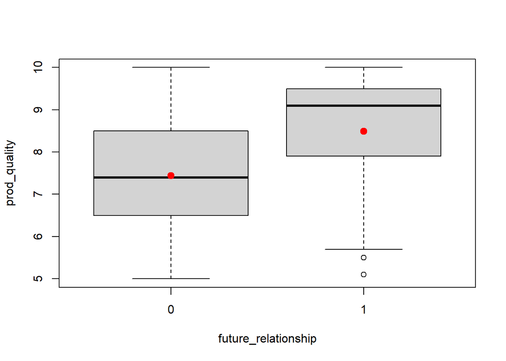

```r
boxplot(prod_quality ~ future_relationship, data = data, names = levels(data$future_relationship))  # descriptive way
means <- tapply(data$prod_quality, data$future_relationship, mean)
points(x = c(1,2), y = means, pch = 19, col = 'red', cex = 1.25)
```

Measure if Median of two groups are equal or not?

```r
wilcox.test(prod_quality ~ future_relationship, data = data, alternative = 'two.sided', paired = F, mu = 0)
```

```
##
##  Wilcoxon rank sum test with continuity correction
##
## data:  prod_quality by future_relationship
## W = 2610, p-value = 1.539e-08
## alternative hypothesis: true location shift is not equal to 0
```

> **result**: the median of two groups is statistically significant different -> product_quality has effect on future_relationship

# 5 Data PreProcessing

## 5.1 Data Manipulation (Changing variable)

### 5.1.1 Min-Max Normalization

```r
summary(data$percentage_purchase)
```

```
##    Min. 1st Qu.  Median    Mean 3rd Qu.    Max.
##   37.10   51.10   58.60   58.20   65.35   77.10
```

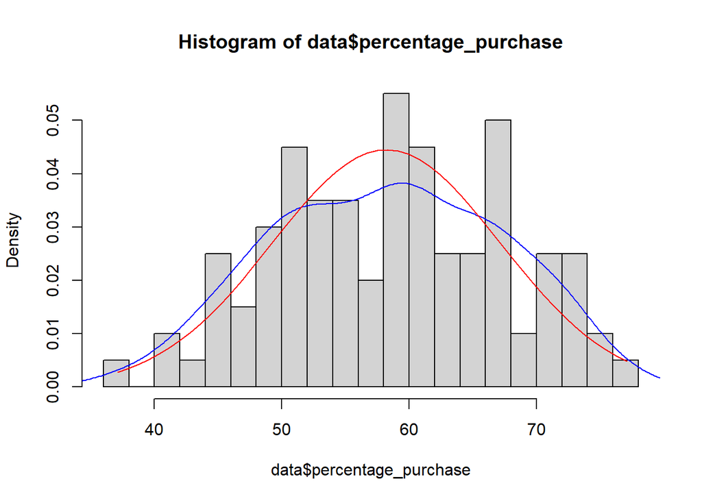

```r
hist(data$percentage_purchase, freq = F, breaks = 20)
lines(density(data$percentage_purchase), col = 'blue')
x_fit <- seq(min(data$percentage_purchase), max(data$percentage_purchase), length.out = 50)
y_fit <- dnorm(x_fit, mean = mean(data$percentage_purchase), sd = sd(data$percentage_purchase))
lines(x_fit, y_fit, col = 'red')
```

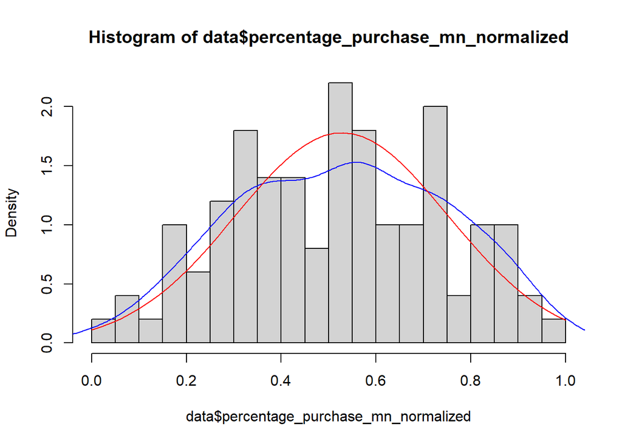

```r
mn_normalize <- function(x) (x - min(x)) / (max(x) - min(x))

data$percentage_purchase_mn_normalized <- mn_normalize(data$percentage_purchase)
hist(data$percentage_purchase_mn_normalized, freq = F, breaks = 20)
lines(density(data$percentage_purchase_mn_normalized), col = 'blue')
x_fit <- seq(min(data$percentage_purchase_mn_normalized), max(data$percentage_purchase_mn_normalized), length.out = 50)
y_fit <- dnorm(x_fit, mean = mean(data$percentage_purchase_mn_normalized), sd = sd(data$percentage_purchase_mn_normalized))
lines(x_fit, y_fit, col = 'red')
```

### 5.1.2 Z-score Normalization

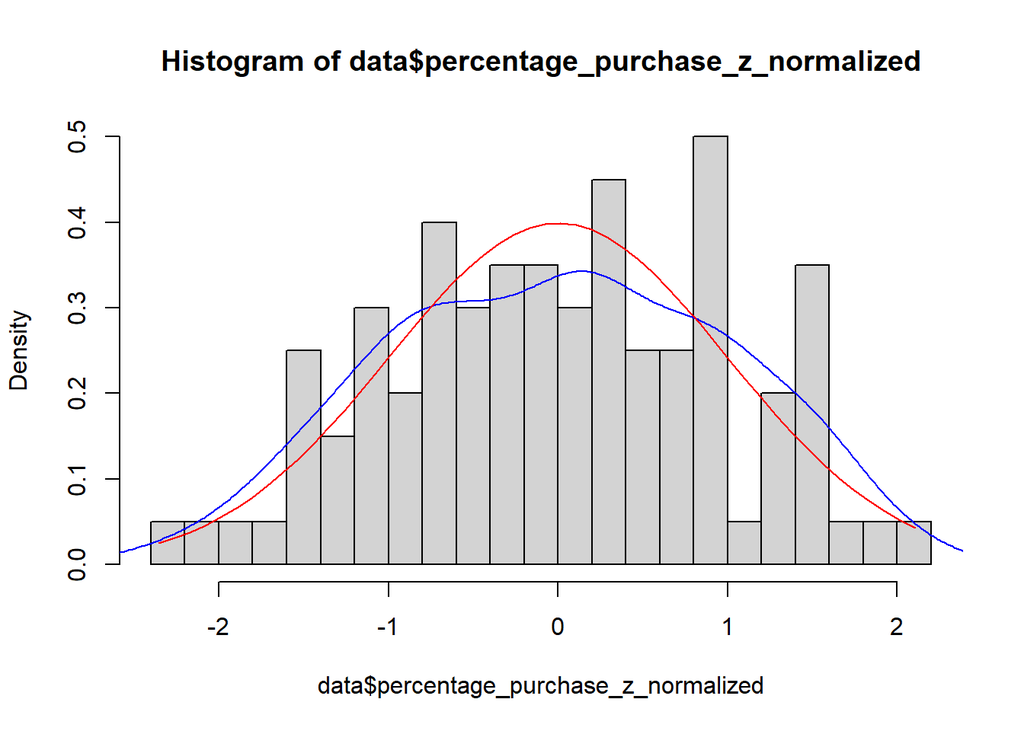

```r
z_normalize <- function(x){
    return((x - mean(x)) / sd(x))
}

data$percentage_purchase_z_normalized <- z_normalize(data$percentage_purchase)
hist(data$percentage_purchase_z_normalized, freq = F, breaks = 20)
lines(density(data$percentage_purchase_z_normalized), col = 'blue')
x_fit <- seq(min(data$percentage_purchase_z_normalized), max(data$percentage_purchase_z_normalized), length.out = 50)
y_fit <- dnorm(x_fit, mean = mean(data$percentage_purchase_z_normalized), sd = sd(data$percentage_purchase_z_normalized))
lines(x_fit, y_fit, col = 'red')
```

### 5.1.3 Linear Transformation

aggregate likelihood_recom and likelihood_purchase (combine to one variable) into future_action: measure prediction of customer behavior in future

```r
summary(data[,c(20,21)])
```

```
##  likelihood_recom likelihood_purchase
##  Min.   :4.000    Min.   :4.300
##  1st Qu.:6.100    1st Qu.:7.100
##  Median :7.000    Median :7.600
##  Mean   :6.952    Mean   :7.665
##  3rd Qu.:7.650    3rd Qu.:8.200
##  Max.   :9.900    Max.   :9.900
```

```r
data$future_action <- 1 / 2 * (data$likelihood_recom + data$likelihood_purchase)  # linear combination
summary(data$future_action)
```

```
##    Min. 1st Qu.  Median    Mean 3rd Qu.    Max.
##   4.150   6.750   7.300   7.309   7.950   9.900
```

### 5.1.4 Discretize data

```r
summary(data$percentage_purchase)
```

```
##    Min. 1st Qu.  Median    Mean 3rd Qu.    Max.
##   37.10   51.10   58.60   58.20   65.35   77.10
```

```r
data$purchase_vol <- ifelse(data$percentage_purchase > median(data$percentage_purchase), 'High', 'Low')
data$purchase_vol
```

```
##   [1] "High" "High" "High" "Low"  "Low"  "Low"  "Low"  "Low"  "Low"  "High"
##  [11] "High" "Low"  "Low"  "High" "High" "High" "Low"  "Low"  "Low"  "High"
##  [21] "Low"  "High" "High" "High" "Low"  "Low"  "High" "Low"  "High" "Low"
##  [31] "Low"  "Low"  "Low"  "High" "Low"  "Low"  "Low"  "High" "High" "Low"
##  [41] "High" "High" "High" "Low"  "High" "Low"  "High" "High" "High" "High"
##  [51] "Low"  "High" "High" "Low"  "High" "High" "High" "Low"  "High" "High"
##  [61] "High" "High" "Low"  "Low"  "Low"  "High" "Low"  "Low"  "Low"  "Low"
##  [71] "High" "Low"  "High" "High" "High" "High" "Low"  "High" "High" "Low"
##  [81] "High" "High" "Low"  "Low"  "Low"  "Low"  "Low"  "Low"  "High" "High"
##  [91] "Low"  "Low"  "High" "High" "High" "Low"  "Low"  "Low"  "High" "Low"
## [101] "Low"  "High" "High" "Low"  "High" "High" "High" "High" "High" "Low"
## [111] "High" "High" "High" "High" "High" "High" "High" "Low"  "Low"  "Low"
## [121] "High" "Low"  "Low"  "High" "Low"  "Low"  "High" "Low"  "High" "Low"
## [131] "High" "High" "Low"  "Low"  "Low"  "High" "Low"  "High" "Low"  "Low"
## [141] "Low"  "High" "High" "High" "High" "High" "Low"  "Low"  "Low"  "Low"
## [151] "High" "Low"  "Low"  "High" "Low"  "High" "Low"  "Low"  "Low"  "High"
## [161] "Low"  "High" "Low"  "Low"  "Low"  "Low"  "Low"  "Low"  "Low"  "Low"
## [171] "Low"  "High" "High" "Low"  "Low"  "High" "High" "High" "High" "High"
## [181] "Low"  "High" "High" "High" "High" "High" "Low"  "Low"  "Low"  "High"
## [191] "Low"  "High" "Low"  "Low"  "Low"  "Low"  "High" "High" "High" "High"
```

### 5.1.5 Transform Skewed data to Normal data

```r
data$prod_quality  # our data is skewed to left and is not normal, we want to close it to normal
```

```
##   [1]  8.5  8.2  9.2  6.4  9.0  6.5  6.9  6.2  5.8  6.4  8.7  6.1  9.5  9.2  6.3
##  [16]  8.7  5.7  5.9  5.6  9.1  5.2  9.6  8.6  9.3  6.0  6.4  8.5  7.0  8.5  7.6
##  [31]  6.9  8.1  6.7  8.0  6.7  8.7  9.0  9.6  8.2  6.1  8.3  9.4  9.3  5.1  8.0
##  [46]  5.9 10.0  5.7  9.9  7.9  6.7  8.2  9.4  6.9  8.0  9.3  7.4  7.6 10.0  9.9
##  [61]  8.7  8.4  8.8  7.7  6.6  5.7  5.7  5.5  7.5  6.4  9.1  6.7  6.5  9.9  8.5
##  [76]  9.9  7.6  9.4  9.3  7.1  9.9  8.7  8.6  6.4  7.7  7.5  5.0  7.7  9.1  5.5
##  [91]  9.1  7.1  9.2  9.3  9.3  8.6  7.4  8.7  7.8  7.9  7.6  9.2  7.7  9.5  6.5
## [106]  8.3  9.6  5.9  8.7  6.7  9.7  8.8  8.2  8.9  8.4  7.7  9.2  7.3  9.0  8.1
## [121]  7.4  7.9  7.7  9.4  7.2  8.3  7.9  7.3  9.6  8.3  8.6  8.0  6.4  6.6  7.6
## [136]  9.4  8.3  7.8  7.1  7.6  5.6  9.9  9.2  9.1  9.9  9.9  6.6  9.1  5.1  6.0
## [151]  8.9  6.2  7.2  8.8  6.3  9.7  5.0  7.4  5.5  9.1  6.7  6.3  8.3  8.2  8.2
## [166]  9.0  7.1  6.9  8.6  6.7  7.0  9.7  9.9  8.6  6.3  9.9  9.3  9.7  9.7  9.6
## [181]  7.6  9.4  9.6  9.3  9.7  9.1  6.5  6.6  5.8  8.7  8.8  6.4  6.7  5.2  6.4
## [196]  7.6  5.9  9.7  5.5  9.7
```

Manual transformation (to make a variable Normal: decrease its skewness)

```r
log_prod_quality <- log(max(data$prod_quality) + 0.001 - data$prod_quality)  # classic changing variable technique
```

Test of distribution Normality

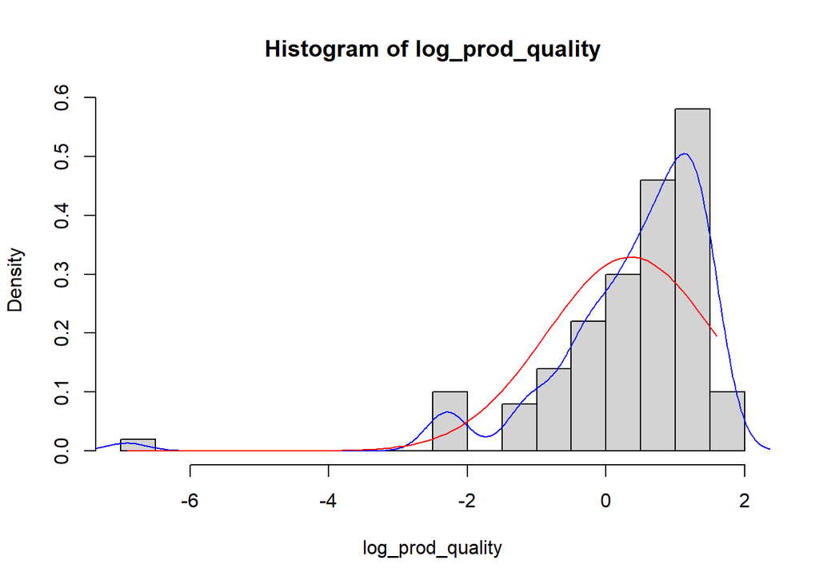

```r
hist(log_prod_quality, freq=F, breaks=15)
lines(density(log_prod_quality), col='blue')
x_fit <- seq(min(log_prod_quality), max(log_prod_quality), by=0.1)
y_fit <- dnorm(x_fit, mean=mean(log_prod_quality), sd=sd(log_prod_quality))
lines(x_fit, y_fit, col='red')
```

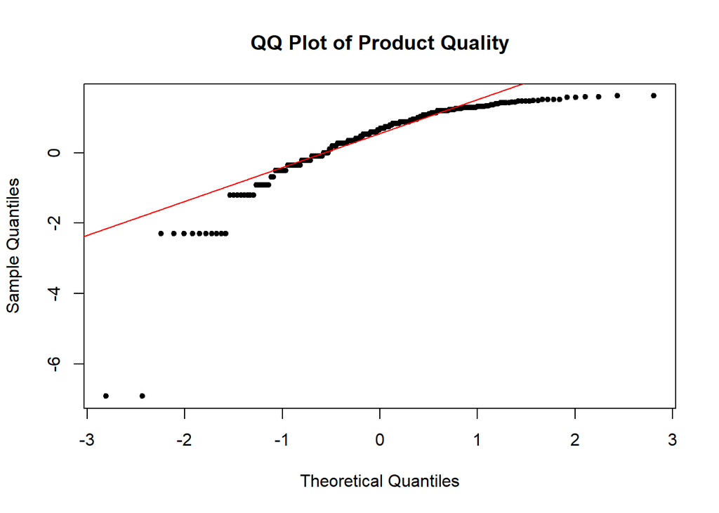

```r
qqnorm(log_prod_quality, main='QQ Plot of Product Quality', pch=20)
qqline(log_prod_quality, col='red')
```

```r
# Normality test
#H0 (Null) assumption: data is from normal distribution
#H1 (Alternative) assumption: data is not from normal distribution
#p-value < 0.05 reject normality assumption (reject H0)
shapiro.test(log_prod_quality)
```

```
##
##  Shapiro-Wilk normality test
##
## data:  log_prod_quality
## W = 0.77219, p-value = 2.476e-16
```

```r
# Skewness test
#H0 (Null) assumption: sample skewness is equal to 0
#H1 (Alternative) assumption: sample skewness is not equal to 0
#p-value < 0.05 reject normality assumption
jarque.test(log_prod_quality)
```

```
##
##  Jarque-Bera Normality Test
##
## data:  log_prod_quality
## JB = 1337.5, p-value < 2.2e-16
## alternative hypothesis: greater
```

```r
# Kurtosis test
#H0 (Null) assumption: sample kurtosis is equal to 3 (normal distribution kurtosis)
#H1 (Alternative) assumption: sample kurtosis is not equal to 3
#p-value < 0.05 reject normality assumption
anscombe.test(log_prod_quality)
```

```
##
##  Anscombe-Glynn kurtosis test
##
## data:  log_prod_quality
## kurt = 14.5077, z = 7.1598, p-value = 8.08e-13
## alternative hypothesis: kurtosis is not equal to 3
```

> **Conclusion**: this transformation could not close prod_quality to normal distribution -> keep going prod_quality transformation manually to see which transformation close it to normal (not recommended)

Box-Cox transformation (to make a variable Normal: decrease its skewness)

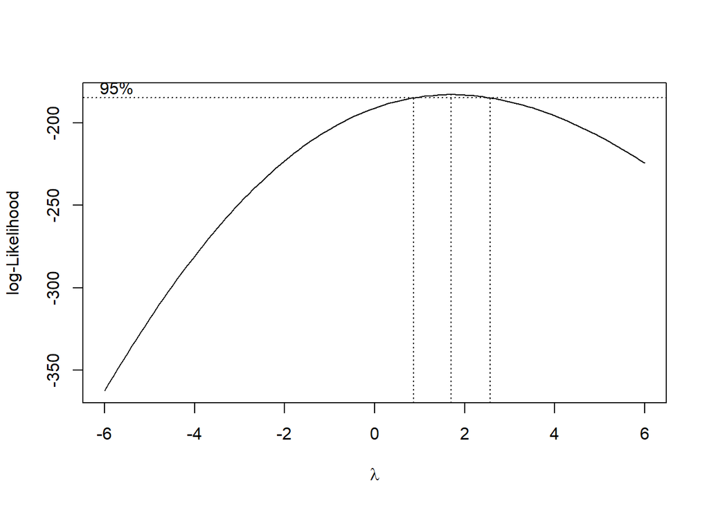

```r
box_results <- boxcox(data$prod_quality ~ 1, lambda = seq(-6, 6, by = 0.1))
```

```r
class(box_results)
```

```
## [1] "list"
```

```r
box_results  # x:searched lambdas, y:log(likelihood)
```

```
## $x
##   [1] -6.0 -5.9 -5.8 -5.7 -5.6 -5.5 -5.4 -5.3 -5.2 -5.1 -5.0 -4.9 -4.8 -4.7 -4.6
##  [16] -4.5 -4.4 -4.3 -4.2 -4.1 -4.0 -3.9 -3.8 -3.7 -3.6 -3.5 -3.4 -3.3 -3.2 -3.1
##  [31] -3.0 -2.9 -2.8 -2.7 -2.6 -2.5 -2.4 -2.3 -2.2 -2.1 -2.0 -1.9 -1.8 -1.7 -1.6
##  [46] -1.5 -1.4 -1.3 -1.2 -1.1 -1.0 -0.9 -0.8 -0.7 -0.6 -0.5 -0.4 -0.3 -0.2 -0.1
##  [61]  0.0  0.1  0.2  0.3  0.4  0.5  0.6  0.7  0.8  0.9  1.0  1.1  1.2  1.3  1.4
##  [76]  1.5  1.6  1.7  1.8  1.9  2.0  2.1  2.2  2.3  2.4  2.5  2.6  2.7  2.8  2.9
##  [91]  3.0  3.1  3.2  3.3  3.4  3.5  3.6  3.7  3.8  3.9  4.0  4.1  4.2  4.3  4.4
## [106]  4.5  4.6  4.7  4.8  4.9  5.0  5.1  5.2  5.3  5.4  5.5  5.6  5.7  5.8  5.9
## [121]  6.0
##
## $y
##   [1] -362.5415 -357.9425 -353.3938 -348.8960 -344.4497 -340.0554 -335.7139
##   [8] -331.4257 -327.1913 -323.0114 -318.8865 -314.8172 -310.8040 -306.8474
##  [15] -302.9481 -299.1065 -295.3231 -291.5984 -287.9328 -284.3270 -280.7812
##  [22] -277.2959 -273.8716 -270.5086 -267.2074 -263.9682 -260.7915 -257.6775
##  [29] -254.6265 -251.6389 -248.7149 -245.8548 -243.0587 -240.3269 -237.6595
##  [36] -235.0567 -232.5186 -230.0454 -227.6370 -225.2937 -223.0154 -220.8021
##  [43] -218.6539 -216.5707 -214.5524 -212.5990 -210.7104 -208.8865 -207.1271
##  [50] -205.4321 -203.8013 -202.2345 -200.7315 -199.2919 -197.9157 -196.6024
##  [57] -195.3519 -194.1637 -193.0376 -191.9731 -190.9700 -190.0279 -189.1463
##  [64] -188.3249 -187.5632 -186.8608 -186.2173 -185.6322 -185.1050 -184.6352
##  [71] -184.2225 -183.8662 -183.5658 -183.3209 -183.1310 -182.9954 -182.9138
##  [78] -182.8854 -182.9099 -182.9866 -183.1150 -183.2946 -183.5248 -183.8050
##  [85] -184.1346 -184.5133 -184.9402 -185.4150 -185.9370 -186.5057 -187.1205
##  [92] -187.7808 -188.4862 -189.2359 -190.0296 -190.8667 -191.7465 -192.6686
##  [99] -193.6324 -194.6373 -195.6829 -196.7686 -197.8938 -199.0581 -200.2610
## [106] -201.5019 -202.7802 -204.0956 -205.4475 -206.8354 -208.2589 -209.7173
## [113] -211.2104 -212.7375 -214.2982 -215.8921 -217.5188 -219.1776 -220.8683
## [120] -222.5903 -224.3432
```

```r
lambda <- box_results$x[which(box_results$y == max(box_results$y))]  # find the lambda which have maximum log_likelihood
boxcox_prod_quality <- (data$prod_quality ^ lambda - 1) / lambda
```

test of distribution Normality

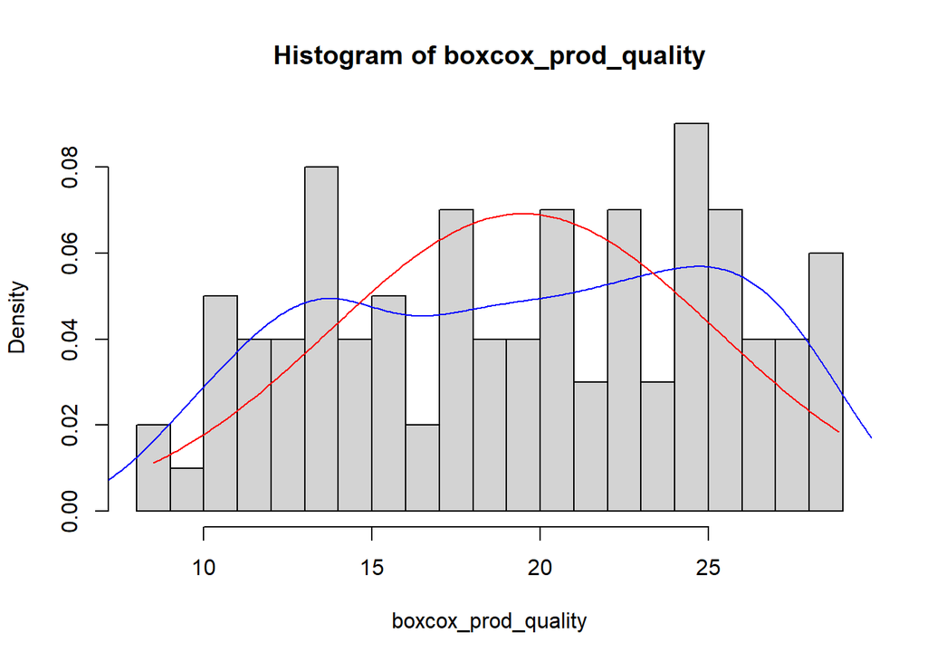

```r
hist(boxcox_prod_quality, freq=F, breaks=15)
lines(density(boxcox_prod_quality), col='blue')
x_fit <- seq(min(boxcox_prod_quality), max(boxcox_prod_quality), by=0.1)
y_fit <- dnorm(x_fit, mean=mean(boxcox_prod_quality), sd=sd(boxcox_prod_quality))
lines(x_fit, y_fit, col='red')
```

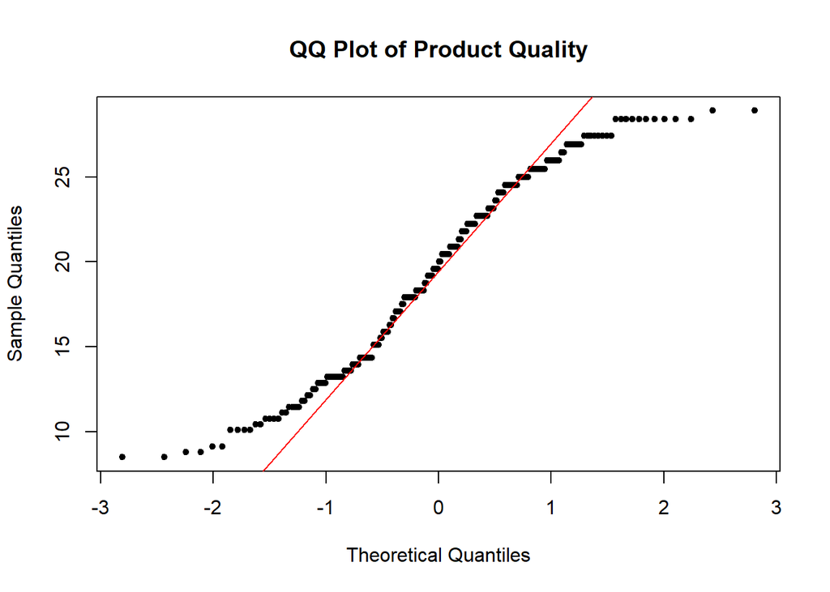

```r
qqnorm(boxcox_prod_quality, main='QQ Plot of Product Quality', pch=20)
qqline(boxcox_prod_quality, col='red')
```

```r
# Normality test
#H0 (Null) assumption: data is from normal distribution
#H1 (Alternative) assumption: data is not from normal distribution
#p-value < 0.05 reject normality assumption (reject H0)
shapiro.test(boxcox_prod_quality)
```

```
##
##  Shapiro-Wilk normality test
##
## data:  boxcox_prod_quality
## W = 0.95289, p-value = 3.618e-06
```

```r
# Skewness test
#H0 (Null) assumption: sample skewness is equal to 0
#H1 (Alternative) assumption: sample skewness is not equal to 0
#p-value < 0.05 reject normality assumption
jarque.test(boxcox_prod_quality)
```

```
##
##  Jarque-Bera Normality Test
##
## data:  boxcox_prod_quality
## JB = 12.278, p-value = 0.002157
## alternative hypothesis: greater
```

```r
# Kurtosis test
#H0 (Null) assumption: sample kurtosis is equal to 3 (normal distribution kurtosis)
#H1 (Alternative) assumption: sample kurtosis is not equal to 3
#p-value < 0.05 reject normality assumption
anscombe.test(boxcox_prod_quality)
```

```
##
##  Anscombe-Glynn kurtosis test
##
## data:  boxcox_prod_quality
## kurt = 1.8136, z = -9.2504, p-value < 2.2e-16
## alternative hypothesis: kurtosis is not equal to 3
```

> **Conclusion**: this transformation could not close prod_quality to normal distribution

## 5.2 Recognize and Dealing with Missing Values

### 5.2.1 Correlation Analysis with Missing Data (we can not calculate Correlation when have NAs)

Determine the type of MVs in our sample (know the cause of having NAs)

```r
data_mv
```

| ID | V1 | V2 | V3 | V4 | V5 | V6 | V7 | V8 | V9 | V10 | V11 | V12 | V13 | V14 |
| --- | --- | --- | --- | --- | --- | --- | --- | --- | --- | --- | --- | --- | --- | --- |
| 201 | 3.3 | 0.9 | 8.6 | 4 | 2.1 | 1.8 | 6.3 | 41 | 4.5 | 0 | 1 | 0 | 0 | 2 |
| 202 | . | 0.4 | . | 2.5 | 1.2 | 1.7 | 5.2 | 35 | 3.3 | 0 | 1 | 0 | 0 | 1 |
| 203 | 3 | . | 9.1 | 7.1 | 3.5 | 3.4 | . | 55 | 5.2 | 0 | 1 | 1 | 0 | 3 |
| 204 | . | 1.5 | . | 4.8 | 1.9 | 2.5 | 7.2 | 36 | . | 1 | 0 | 1 | 0 | 1 |
| 205 | 5.1 | 1.4 | . | 4.8 | 3.3 | 2.6 | 3.8 | 49 | 4.9 | 0 | 1 | 0 | 0 | 2 |
| 206 | 4.6 | 2.1 | 7.9 | 5.8 | 3.4 | 2.8 | 4.7 | 49 | 5.9 | 0 | 1 | 0 | 1 | 3 |
| 207 | . | 1.5 | . | 4.8 | 1.9 | 2.5 | 7.2 | 36 | . | 1 | 0 | 1 | 0 | 1 |
| 208 | 5.2 | 1.3 | 9.7 | 6.1 | 3.2 | 3.9 | 6.7 | 54 | 5.8 | 0 | 1 | 0 | 1 | 3 |
| 209 | 3.5 | 2.8 | 9.9 | 3.5 | 3.1 | 1.7 | 5.4 | 49 | 5.4 | 0 | 1 | 0 | 1 | 3 |
| 210 | 4.1 | 3.7 | 5.9 | . | . | . | . | . | . | . | 0 | 1 | 0 | 2 |

[output cut: 60 more lines]

Determine the Extent of MVs in our data

```r
summary(data_mv)
```

```
##        ID             V1                 V2                 V3
##  Min.   :201.0   Length:70          Length:70          Length:70
##  1st Qu.:218.2   Class :character   Class :character   Class :character
##  Median :235.5   Mode  :character   Mode  :character   Mode  :character
##  Mean   :235.5
##  3rd Qu.:252.8
##  Max.   :270.0
##       V4                 V5                 V6                 V7
##  Length:70          Length:70          Length:70          Length:70
##  Class :character   Class :character   Class :character   Class :character
##  Mode  :character   Mode  :character   Mode  :character   Mode  :character
##
##
##
##       V8                 V9                V10                V11
##  Length:70          Length:70          Length:70          Length:70
##  Class :character   Class :character   Class :character   Class :character
##  Mode  :character   Mode  :character   Mode  :character   Mode  :character
##
##
##
##      V12                V13                V14
##  Length:70          Length:70          Length:70
##  Class :character   Class :character   Class :character
##  Mode  :character   Mode  :character   Mode  :character
##
##
##
```

```r
data_mv[data_mv == '.'] <- NA  # replace '.' with NA (Not-Available)
data_mv[,2:10] <- lapply(data_mv[,2:10], as.numeric)  # convert columns 2 to 10 to numeric
data_mv[,11:15] <- lapply(data_mv[,11:15], as.factor)  # convert columns 11 to 15 to factor
summary(data_mv)
```

```
##        ID              V1              V2              V3
##  Min.   :201.0   Min.   :2.800   Min.   :0.400   Min.   :5.000
##  1st Qu.:218.2   1st Qu.:3.200   1st Qu.:1.400   1st Qu.:6.700
##  Median :235.5   Median :3.800   Median :1.900   Median :8.200
##  Mean   :235.5   Mean   :4.008   Mean   :1.944   Mean   :8.062
##  3rd Qu.:252.8   3rd Qu.:4.700   3rd Qu.:2.500   3rd Qu.:9.200
##  Max.   :270.0   Max.   :6.500   Max.   :3.800   Max.   :9.900
##                  NA's   :21      NA's   :13      NA's   :17
##        V4              V5              V6              V7
##  Min.   :2.500   Min.   :1.100   Min.   :1.100   Min.   :1.700
##  1st Qu.:4.500   1st Qu.:2.200   1st Qu.:2.275   1st Qu.:5.600
##  Median :5.000   Median :3.000   Median :2.600   Median :6.800
##  Mean   :5.168   Mean   :2.856   Mean   :2.611   Mean   :6.823
##  3rd Qu.:5.900   3rd Qu.:3.400   3rd Qu.:3.000   3rd Qu.:8.200
##  Max.   :7.800   Max.   :4.600   Max.   :4.000   Max.   :9.900
##  NA's   :7       NA's   :9       NA's   :6       NA's   :9
##        V8              V9          V10       V11       V12       V13
##  Min.   :25.00   Min.   :3.300   0   :43   0   :24   0   :37   0   :36
##  1st Qu.:39.00   1st Qu.:4.150   1   :25   1   :44   1   :31   1   :33
##  Median :47.00   Median :4.900   NA's: 2   NA's: 2   NA's: 2   NA's: 1
##  Mean   :46.03   Mean   :4.759
##  3rd Qu.:54.00   3rd Qu.:5.250
##  Max.   :65.00   Max.   :6.200
##  NA's   :9       NA's   :7
##    V14
##  1   :22
##  2   :22
##  3   :24
##  NA's: 2
##
##
##
```

Variable aspect: NA count by columns

```r
mv_summary_1 <- data.frame(variable_names = colnames(data_mv))
mv_summary_1$mvs_freq <- apply(data_mv, 2, function(x) sum(is.na(x)))  # frequency of NAs in each variable
mv_summary_1$mvs_percent <- round(mv_summary_1$mvs_freq / nrow(data_mv), 3) * 100
mv_summary_1  # NA count and percentage in each variable
```

| variable_names | mvs_freq | mvs_percent |
| --- | --- | --- |
| ID | 0 | 0.0 |
| V1 | 21 | 30.0 |
| V2 | 13 | 18.6 |
| V3 | 17 | 24.3 |
| V4 | 7 | 10.0 |
| V5 | 9 | 12.9 |
| V6 | 6 | 8.6 |
| V7 | 9 | 12.9 |
| V8 | 9 | 12.9 |
| V9 | 7 | 10.0 |

[output cut: 5 more lines]

Case aspect: NA count by rows

```r
mv_summary_2 <- as.data.frame(table(apply(data_mv, 1, function(x) sum(is.na(x)))))  # frequencey of NAs in each row
colnames(mv_summary_2) <- c('mvs_per_case', 'mvs_freq')
mv_summary_2$mvs_percent <- round(mv_summary_2$mvs_freq / nrow(data_mv), 3) * 100
mv_summary_2$mvs_per_case <- as.numeric(levels(mv_summary_2$mvs_per_case))
mv_summary_2$mvs_per_case_percent <- round(mv_summary_2$mvs_per_case / (ncol(data_mv) - 1), 3) * 100
mv_summary_2[c(1,4,2,3)]
```

| mvs_per_case | mvs_per_case_percent | mvs_freq | mvs_percent |
| --- | --- | --- | --- |
| 0 | 0.0 | 26 | 37.1 |
| 1 | 7.1 | 15 | 21.4 |
| 2 | 14.3 | 19 | 27.1 |
| 3 | 21.4 | 4 | 5.7 |
| 7 | 50.0 | 6 | 8.6 |

Check Patterns of Missing Data by Case (Observation)

```r
data_w_mvs <- data_mv[apply(data_mv, 1, function(x) any(is.na(x))), ]  # choose observation with at-least one NA
data_w_mvs$mvs_count <- apply(data_w_mvs, 1, function(x) sum(is.na(x)))
data_w_mvs
```

|  | ID | V1 | V2 | V3 | V4 | V5 | V6 | V7 | V8 | V9 | V10 | V11 | V12 | V13 | V14 | mvs_count |
| --- | --- | --- | --- | --- | --- | --- | --- | --- | --- | --- | --- | --- | --- | --- | --- | --- |
| 2 | 202 | NA | 0.4 | NA | 2.5 | 1.2 | 1.7 | 5.2 | 35 | 3.3 | 0 | 1 | 0 | 0 | 1 | 2 |
| 3 | 203 | 3.0 | NA | 9.1 | 7.1 | 3.5 | 3.4 | NA | 55 | 5.2 | 0 | 1 | 1 | 0 | 3 | 2 |
| 4 | 204 | NA | 1.5 | NA | 4.8 | 1.9 | 2.5 | 7.2 | 36 | NA | 1 | 0 | 1 | 0 | 1 | 3 |
| 5 | 205 | 5.1 | 1.4 | NA | 4.8 | 3.3 | 2.6 | 3.8 | 49 | 4.9 | 0 | 1 | 0 | 0 | 2 | 1 |
| 7 | 207 | NA | 1.5 | NA | 4.8 | 1.9 | 2.5 | 7.2 | 36 | NA | 1 | 0 | 1 | 0 | 1 | 3 |
| 10 | 210 | 4.1 | 3.7 | 5.9 | NA | NA | NA | NA | NA | NA | NA | 0 | 1 | 0 | 2 | 7 |
| 13 | 213 | 3.1 | NA | NA | 7.8 | 3.6 | 4.0 | 5.9 | 43 | 5.2 | 0 | 1 | 1 | 1 | 2 | 2 |
| 14 | 214 | NA | 2.7 | 5.0 | NA | 2.2 | NA | NA | NA | 3.6 | 1 | NA | 1 | NA | 1 | 7 |
| 16 | 216 | NA | 1.6 | 6.4 | 5.0 | NA | 2.1 | 8.4 | 25 | 3.4 | 1 | 0 | 1 | 1 | 1 | 2 |
| 18 | 218 | NA | 2.8 | 5.2 | 5.0 | NA | 2.7 | 8.4 | 38 | 3.7 | 1 | 0 | 1 | 0 | 1 | 2 |

[output cut: 34 more lines]

**Decision**: remove variable V1 (30% NAs -> systematic NAs)and cases with 50% and more NAs from dataset (ID: 210, 214, 233, 245, 261, 263 -> have not enough quality for analysis)

```r
data_mv_1 <- data_mv[- which(data_mv$ID %in% data_w_mvs[which(data_w_mvs$mvs_count >= 7), 1]), ]
data_mv_1 <- data_mv_1[,-2]
dim(data_mv_1)
```

```
## [1] 64 14
```

```r
data_mv_1
```

|  | ID | V2 | V3 | V4 | V5 | V6 | V7 | V8 | V9 | V10 | V11 | V12 | V13 | V14 |
| --- | --- | --- | --- | --- | --- | --- | --- | --- | --- | --- | --- | --- | --- | --- |
| 1 | 201 | 0.9 | 8.6 | 4.0 | 2.1 | 1.8 | 6.3 | 41 | 4.5 | 0 | 1 | 0 | 0 | 2 |
| 2 | 202 | 0.4 | NA | 2.5 | 1.2 | 1.7 | 5.2 | 35 | 3.3 | 0 | 1 | 0 | 0 | 1 |
| 3 | 203 | NA | 9.1 | 7.1 | 3.5 | 3.4 | NA | 55 | 5.2 | 0 | 1 | 1 | 0 | 3 |
| 4 | 204 | 1.5 | NA | 4.8 | 1.9 | 2.5 | 7.2 | 36 | NA | 1 | 0 | 1 | 0 | 1 |
| 5 | 205 | 1.4 | NA | 4.8 | 3.3 | 2.6 | 3.8 | 49 | 4.9 | 0 | 1 | 0 | 0 | 2 |
| 6 | 206 | 2.1 | 7.9 | 5.8 | 3.4 | 2.8 | 4.7 | 49 | 5.9 | 0 | 1 | 0 | 1 | 3 |
| 7 | 207 | 1.5 | NA | 4.8 | 1.9 | 2.5 | 7.2 | 36 | NA | 1 | 0 | 1 | 0 | 1 |
| 8 | 208 | 1.3 | 9.7 | 6.1 | 3.2 | 3.9 | 6.7 | 54 | 5.8 | 0 | 1 | 0 | 1 | 3 |
| 9 | 209 | 2.8 | 9.9 | 3.5 | 3.1 | 1.7 | 5.4 | 49 | 5.4 | 0 | 1 | 0 | 1 | 3 |
| 11 | 211 | 2.8 | 7.8 | 7.1 | 3.0 | 3.8 | 7.9 | 49 | 4.4 | 0 | 1 | 1 | 1 | 2 |

[output cut: 54 more lines]

Select and Use the Imputation method

**method 1**: Complete Case Approach (just use complete rows)

```r
data_1_comp <- data_mv_1[apply(data_mv_1, 1, function(x) any(is.na(x))) == F, ]
data_1_comp
```

|  | ID | V2 | V3 | V4 | V5 | V6 | V7 | V8 | V9 | V10 | V11 | V12 | V13 | V14 |
| --- | --- | --- | --- | --- | --- | --- | --- | --- | --- | --- | --- | --- | --- | --- |
| 1 | 201 | 0.9 | 8.6 | 4.0 | 2.1 | 1.8 | 6.3 | 41 | 4.5 | 0 | 1 | 0 | 0 | 2 |
| 6 | 206 | 2.1 | 7.9 | 5.8 | 3.4 | 2.8 | 4.7 | 49 | 5.9 | 0 | 1 | 0 | 1 | 3 |
| 8 | 208 | 1.3 | 9.7 | 6.1 | 3.2 | 3.9 | 6.7 | 54 | 5.8 | 0 | 1 | 0 | 1 | 3 |
| 9 | 209 | 2.8 | 9.9 | 3.5 | 3.1 | 1.7 | 5.4 | 49 | 5.4 | 0 | 1 | 0 | 1 | 3 |
| 11 | 211 | 2.8 | 7.8 | 7.1 | 3.0 | 3.8 | 7.9 | 49 | 4.4 | 0 | 1 | 1 | 1 | 2 |
| 12 | 212 | 1.7 | 7.6 | 4.2 | 3.3 | 1.4 | 5.8 | 39 | 5.5 | 0 | 1 | 0 | 0 | 2 |
| 15 | 215 | 0.5 | 6.7 | 4.5 | 2.2 | 2.1 | 5.0 | 31 | 4.0 | 0 | 1 | 0 | 1 | 1 |
| 17 | 217 | 0.5 | 9.2 | 4.8 | 3.3 | 2.8 | 7.1 | 60 | 5.2 | 0 | 1 | 0 | 1 | 3 |
| 23 | 223 | 1.4 | 8.1 | 3.8 | 2.1 | 1.4 | 6.6 | 39 | 4.4 | 1 | 0 | 1 | 0 | 1 |
| 26 | 226 | 2.0 | 9.7 | 4.7 | 2.7 | 1.7 | 4.8 | 49 | 4.7 | 0 | 1 | 0 | 0 | 3 |

[output cut: 22 more lines]

```r
mean_imput_comp <- data.frame(apply(data_1_comp[2:9], 2, mean))
colnames(mean_imput_comp) <- 'all_case'
mean_imput_comp
```

|  | all_case |
| --- | --- |
| V2 | 2.003125 |
| V3 | 8.337500 |
| V4 | 5.171875 |
| V5 | 2.881250 |
| V6 | 2.543750 |
| V7 | 6.715625 |
| V8 | 47.718750 |
| V9 | 4.850000 |

```r
sd_imput_comp <- data.frame(apply(data_1_comp[2:9], 2, sd))
colnames(sd_imput_comp) <- 'all_case'
sd_imput_comp
```

|  | all_case |
| --- | --- |
| V2 | 0.8403088 |
| V3 | 1.2140973 |
| V4 | 1.1124615 |
| V5 | 0.6850653 |
| V6 | 0.7206348 |
| V7 | 1.6894568 |
| V8 | 9.6694877 |
| V9 | 0.8784150 |

**method 2**: Mean Substitution (replace NA with mean(column))

```r
data_1_mean_sub <- data_mv_1
for (i in 2:9){
    data_1_mean_sub[is.na(data_1_mean_sub[,i]),i] <- mean(data_1_mean_sub[,i], na.rm = T)
}
data_1_mean_sub
```

|  | ID | V2 | V3 | V4 | V5 | V6 | V7 | V8 | V9 | V10 | V11 | V12 | V13 | V14 |
| --- | --- | --- | --- | --- | --- | --- | --- | --- | --- | --- | --- | --- | --- | --- |
| 1 | 201 | 0.900000 | 8.60 | 4.000000 | 2.100000 | 1.800000 | 6.30 | 41.00000 | 4.500000 | 0 | 1 | 0 | 0 | 2 |
| 2 | 202 | 0.400000 | 8.13 | 2.500000 | 1.200000 | 1.700000 | 5.20 | 35.00000 | 3.300000 | 0 | 1 | 0 | 0 | 1 |
| 3 | 203 | 1.896296 | 9.10 | 7.100000 | 3.500000 | 3.400000 | 6.79 | 55.00000 | 5.200000 | 0 | 1 | 1 | 0 | 3 |
| 4 | 204 | 1.500000 | 8.13 | 4.800000 | 1.900000 | 2.500000 | 7.20 | 36.00000 | 4.798333 | 1 | 0 | 1 | 0 | 1 |
| 5 | 205 | 1.400000 | 8.13 | 4.800000 | 3.300000 | 2.600000 | 3.80 | 49.00000 | 4.900000 | 0 | 1 | 0 | 0 | 2 |
| 6 | 206 | 2.100000 | 7.90 | 5.800000 | 3.400000 | 2.800000 | 4.70 | 49.00000 | 5.900000 | 0 | 1 | 0 | 1 | 3 |
| 7 | 207 | 1.500000 | 8.13 | 4.800000 | 1.900000 | 2.500000 | 7.20 | 36.00000 | 4.798333 | 1 | 0 | 1 | 0 | 1 |
| 8 | 208 | 1.300000 | 9.70 | 6.100000 | 3.200000 | 3.900000 | 6.70 | 54.00000 | 5.800000 | 0 | 1 | 0 | 1 | 3 |
| 9 | 209 | 2.800000 | 9.90 | 3.500000 | 3.100000 | 1.700000 | 5.40 | 49.00000 | 5.400000 | 0 | 1 | 0 | 1 | 3 |
| 11 | 211 | 2.800000 | 7.80 | 7.100000 | 3.000000 | 3.800000 | 7.90 | 49.00000 | 4.400000 | 0 | 1 | 1 | 1 | 2 |

[output cut: 54 more lines]

```r
mean_imput_comp$mean_sub <- apply(data_1_mean_sub[2:9], 2, mean)
mean_imput_comp
```

|  | all_case | mean_sub |
| --- | --- | --- |
| V2 | 2.003125 | 1.896296 |
| V3 | 8.337500 | 8.130000 |
| V4 | 5.171875 | 5.146667 |
| V5 | 2.881250 | 2.838983 |
| V6 | 2.543750 | 2.601587 |
| V7 | 6.715625 | 6.790000 |
| V8 | 47.718750 | 45.966667 |
| V9 | 4.850000 | 4.798333 |

```r
sd_imput_comp$mean_sub <- apply(data_1_mean_sub[2:9], 2, sd)
sd_imput_comp
```

|  | all_case | mean_sub |
| --- | --- | --- |
| V2 | 0.8403088 | 0.7877964 |
| V3 | 1.2140973 | 1.1636355 |
| V4 | 1.1124615 | 1.1493914 |
| V5 | 0.6850653 | 0.7235312 |
| V6 | 0.7206348 | 0.7134740 |
| V7 | 1.6894568 | 1.6210618 |
| V8 | 9.6694877 | 9.1164715 |
| V9 | 0.8784150 | 0.7929234 |

**method 3**: Regression Imputation

```r
data_1_reg <- data_mv_1
imp_reg <- mice(data_1_reg[,2:9], method = 'norm.predict', m = 5)
class(imp_reg)
```

```
## [1] "mids"
```

```r
data_1_reg[,2:9] <- complete(imp_reg)
data_1_reg
```

|  | ID | V2 | V3 | V4 | V5 | V6 | V7 | V8 | V9 | V10 | V11 | V12 | V13 | V14 |
| --- | --- | --- | --- | --- | --- | --- | --- | --- | --- | --- | --- | --- | --- | --- |
| 1 | 201 | 0.900000 | 8.600000 | 4.000000 | 2.100000 | 1.800000 | 6.300000 | 41.00000 | 4.500000 | 0 | 1 | 0 | 0 | 2 |
| 2 | 202 | 0.400000 | 8.004895 | 2.500000 | 1.200000 | 1.700000 | 5.200000 | 35.00000 | 3.300000 | 0 | 1 | 0 | 0 | 1 |
| 3 | 203 | 2.651541 | 9.100000 | 7.100000 | 3.500000 | 3.400000 | 8.217071 | 55.00000 | 5.200000 | 0 | 1 | 1 | 0 | 3 |
| 4 | 204 | 1.500000 | 7.734551 | 4.800000 | 1.900000 | 2.500000 | 7.200000 | 36.00000 | 4.102719 | 1 | 0 | 1 | 0 | 1 |
| 5 | 205 | 1.400000 | 7.848205 | 4.800000 | 3.300000 | 2.600000 | 3.800000 | 49.00000 | 4.900000 | 0 | 1 | 0 | 0 | 2 |
| 6 | 206 | 2.100000 | 7.900000 | 5.800000 | 3.400000 | 2.800000 | 4.700000 | 49.00000 | 5.900000 | 0 | 1 | 0 | 1 | 3 |
| 7 | 207 | 1.500000 | 7.721891 | 4.800000 | 1.900000 | 2.500000 | 7.200000 | 36.00000 | 4.098159 | 1 | 0 | 1 | 0 | 1 |
| 8 | 208 | 1.300000 | 9.700000 | 6.100000 | 3.200000 | 3.900000 | 6.700000 | 54.00000 | 5.800000 | 0 | 1 | 0 | 1 | 3 |
| 9 | 209 | 2.800000 | 9.900000 | 3.500000 | 3.100000 | 1.700000 | 5.400000 | 49.00000 | 5.400000 | 0 | 1 | 0 | 1 | 3 |
| 11 | 211 | 2.800000 | 7.800000 | 7.100000 | 3.000000 | 3.800000 | 7.900000 | 49.00000 | 4.400000 | 0 | 1 | 1 | 1 | 2 |

[output cut: 54 more lines]

```r
mean_imput_comp$reg <- apply(data_1_reg[2:9], 2, mean)
mean_imput_comp
```

|  | all_case | mean_sub | reg |
| --- | --- | --- | --- |
| V2 | 2.003125 | 1.896296 | 1.997234 |
| V3 | 8.337500 | 8.130000 | 8.108856 |
| V4 | 5.171875 | 5.146667 | 5.136465 |
| V5 | 2.881250 | 2.838983 | 2.833346 |
| V6 | 2.543750 | 2.601587 | 2.583087 |
| V7 | 6.715625 | 6.790000 | 6.838710 |
| V8 | 47.718750 | 45.966667 | 45.756641 |
| V9 | 4.850000 | 4.798333 | 4.768320 |

```r
sd_imput_comp$reg <- apply(data_1_reg[2:9], 2, sd)
sd_imput_comp
```

|  | all_case | mean_sub | reg |
| --- | --- | --- | --- |
| V2 | 0.8403088 | 0.7877964 | 0.8367436 |
| V3 | 1.2140973 | 1.1636355 | 1.2114191 |
| V4 | 1.1124615 | 1.1493914 | 1.1525334 |
| V5 | 0.6850653 | 0.7235312 | 0.7408034 |
| V6 | 0.7206348 | 0.7134740 | 0.7286635 |
| V7 | 1.6894568 | 1.6210618 | 1.6424231 |
| V8 | 9.6694877 | 9.1164715 | 9.2298121 |
| V9 | 0.8784150 | 0.7929234 | 0.8071987 |

Correlation Analysis

```r
cor(data_1_comp[2:9])  # All Complete Case
```

```
##              V2          V3          V4          V5          V6          V7
## V2  1.000000000 -0.28563666  0.28478451  0.28532847  0.34655580  0.34488901
## V3 -0.285636660  1.00000000 -0.07490495  0.24831469 -0.08710466 -0.40667293
## V4  0.284784511 -0.07490495  1.00000000  0.25875253  0.81841898  0.41834460
## V5  0.285328473  0.24831469  0.25875253  1.00000000  0.31470244 -0.02733142
## V6  0.346555796 -0.08710466  0.81841898  0.31470244  1.00000000  0.54205309
## V7  0.344889014 -0.40667293  0.41834460 -0.02733142  0.54205309  1.00000000
## V8  0.008448761  0.72084472  0.20286055  0.71259034  0.25921442 -0.27064282
## V9 -0.272043897  0.76616139  0.21341361  0.45778804  0.09325549 -0.43201480
##              V8          V9
## V2  0.008448761 -0.27204390
## V3  0.720844723  0.76616139
## V4  0.202860548  0.21341361
## V5  0.712590340  0.45778804
## V6  0.259214424  0.09325549
## V7 -0.270642820 -0.43201480
## V8  1.000000000  0.71000363
## V9  0.710003633  1.00000000
```

```r
cor(data_1_mean_sub[2:9])  # Mean Substitution
```

```
##            V2          V3          V4         V5          V6          V7
## V2  1.0000000 -0.28871558  0.24458691 0.38176054  0.21857162  0.31047922
## V3 -0.2887156  1.00000000 -0.05737506 0.04171352 -0.03187313 -0.29679024
## V4  0.2445869 -0.05737506  1.00000000 0.42204603  0.76913447  0.37394324
## V5  0.3817605  0.04171352  0.42204603 1.00000000  0.32300732  0.06078088
## V6  0.2185716 -0.03187313  0.76913447 0.32300732  1.00000000  0.39480078
## V7  0.3104792 -0.29679024  0.37394324 0.06078088  0.39480078  1.00000000
## V8  0.1339843  0.50258976  0.21569639 0.65642611  0.25998562 -0.19502020
## V9 -0.1727040  0.62613802  0.34432334 0.47677334  0.22873468 -0.24986457
##            V8         V9
## V2  0.1339843 -0.1727040
## V3  0.5025898  0.6261380
## V4  0.2156964  0.3443233
## V5  0.6564261  0.4767733
## V6  0.2599856  0.2287347
## V7 -0.1950202 -0.2498646
## V8  1.0000000  0.6466389
## V9  0.6466389  1.0000000
```

```r
cor(data_1_reg[2:9])  # Regression
```

```
##             V2          V3          V4         V5          V6          V7
## V2  1.00000000 -0.33487734  0.32395921 0.51623886  0.31471758  0.37489973
## V3 -0.33487734  1.00000000 -0.09617261 0.06486034 -0.07835185 -0.30518574
## V4  0.32395921 -0.09617261  1.00000000 0.41190124  0.81315465  0.41260475
## V5  0.51623886  0.06486034  0.41190124 1.00000000  0.38163589  0.03832399
## V6  0.31471758 -0.07835185  0.81315465 0.38163589  1.00000000  0.42363587
## V7  0.37489973 -0.30518574  0.41260475 0.03832399  0.42363587  1.00000000
## V8  0.16190211  0.58115004  0.20144462 0.68845507  0.27081668 -0.19137232
## V9 -0.07577716  0.63442787  0.36426561 0.55923455  0.24004268 -0.24692771
##            V8          V9
## V2  0.1619021 -0.07577716
## V3  0.5811500  0.63442787
## V4  0.2014446  0.36426561
## V5  0.6884551  0.55923455
## V6  0.2708167  0.24004268
## V7 -0.1913723 -0.24692771
## V8  1.0000000  0.68691350
## V9  0.6869135  1.00000000
```

## 5.3 Recognize and Dealing with Outliers

### 5.3.1 Classic method (based-on normal distribution)

```r
(data$percentage_purchase - mean(data$percentage_purchase)) / sd(data$percentage_purchase) > 3
```

```
##   [1] FALSE FALSE FALSE FALSE FALSE FALSE FALSE FALSE FALSE FALSE FALSE FALSE
##  [13] FALSE FALSE FALSE FALSE FALSE FALSE FALSE FALSE FALSE FALSE FALSE FALSE
##  [25] FALSE FALSE FALSE FALSE FALSE FALSE FALSE FALSE FALSE FALSE FALSE FALSE
##  [37] FALSE FALSE FALSE FALSE FALSE FALSE FALSE FALSE FALSE FALSE FALSE FALSE
##  [49] FALSE FALSE FALSE FALSE FALSE FALSE FALSE FALSE FALSE FALSE FALSE FALSE
##  [61] FALSE FALSE FALSE FALSE FALSE FALSE FALSE FALSE FALSE FALSE FALSE FALSE
##  [73] FALSE FALSE FALSE FALSE FALSE FALSE FALSE FALSE FALSE FALSE FALSE FALSE
##  [85] FALSE FALSE FALSE FALSE FALSE FALSE FALSE FALSE FALSE FALSE FALSE FALSE
##  [97] FALSE FALSE FALSE FALSE FALSE FALSE FALSE FALSE FALSE FALSE FALSE FALSE
## [109] FALSE FALSE FALSE FALSE FALSE FALSE FALSE FALSE FALSE FALSE FALSE FALSE
## [121] FALSE FALSE FALSE FALSE FALSE FALSE FALSE FALSE FALSE FALSE FALSE FALSE
## [133] FALSE FALSE FALSE FALSE FALSE FALSE FALSE FALSE FALSE FALSE FALSE FALSE
## [145] FALSE FALSE FALSE FALSE FALSE FALSE FALSE FALSE FALSE FALSE FALSE FALSE
## [157] FALSE FALSE FALSE FALSE FALSE FALSE FALSE FALSE FALSE FALSE FALSE FALSE
## [169] FALSE FALSE FALSE FALSE FALSE FALSE FALSE FALSE FALSE FALSE FALSE FALSE
## [181] FALSE FALSE FALSE FALSE FALSE FALSE FALSE FALSE FALSE FALSE FALSE FALSE
## [193] FALSE FALSE FALSE FALSE FALSE FALSE FALSE FALSE
```

### 5.3.2 Tukey method (based-on quantile logic)

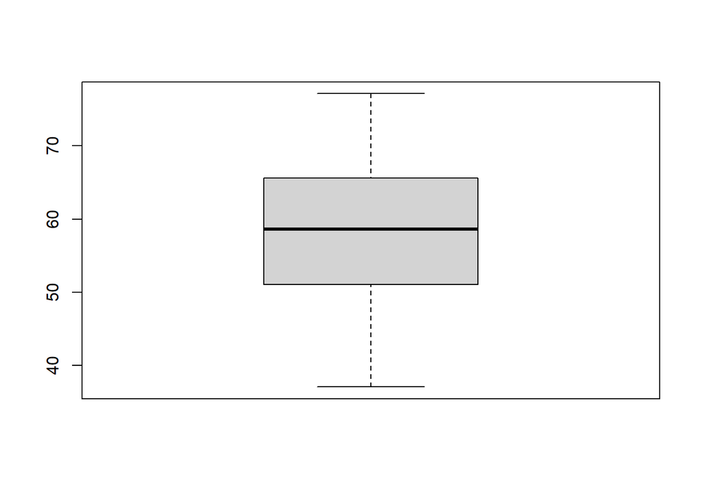

```
## numeric(0)
```

```r
boxplot(data$percentage_purchase)$out
```

### 5.3.3 MAD-Median Rule method

```r
abs(data$percentage_purchase - median(data$percentage_purchase))/mad(data$percentage_purchase) > 2.5
```

```
##   [1] FALSE FALSE FALSE FALSE FALSE FALSE FALSE FALSE FALSE FALSE FALSE FALSE
##  [13] FALSE FALSE FALSE FALSE FALSE FALSE FALSE FALSE FALSE FALSE FALSE FALSE
##  [25] FALSE FALSE FALSE FALSE FALSE FALSE FALSE FALSE FALSE FALSE FALSE FALSE
##  [37] FALSE FALSE FALSE FALSE FALSE FALSE FALSE FALSE FALSE FALSE FALSE FALSE
##  [49] FALSE FALSE FALSE FALSE FALSE FALSE FALSE FALSE FALSE FALSE FALSE FALSE
##  [61] FALSE FALSE FALSE FALSE FALSE FALSE FALSE FALSE FALSE FALSE FALSE FALSE
##  [73] FALSE FALSE FALSE FALSE FALSE FALSE FALSE FALSE FALSE FALSE FALSE FALSE
##  [85] FALSE FALSE FALSE FALSE FALSE FALSE FALSE FALSE FALSE FALSE FALSE FALSE
##  [97] FALSE FALSE FALSE FALSE FALSE FALSE FALSE FALSE FALSE FALSE FALSE FALSE
## [109] FALSE FALSE FALSE FALSE FALSE FALSE FALSE FALSE FALSE FALSE FALSE FALSE
## [121] FALSE FALSE FALSE FALSE FALSE FALSE FALSE FALSE FALSE FALSE FALSE FALSE
## [133] FALSE FALSE FALSE FALSE FALSE FALSE FALSE FALSE FALSE FALSE FALSE FALSE
## [145] FALSE FALSE FALSE FALSE FALSE FALSE FALSE FALSE FALSE FALSE FALSE FALSE
## [157] FALSE FALSE FALSE FALSE FALSE FALSE FALSE FALSE FALSE FALSE FALSE FALSE
## [169] FALSE FALSE FALSE FALSE FALSE FALSE FALSE FALSE FALSE FALSE FALSE FALSE
## [181] FALSE FALSE FALSE FALSE FALSE FALSE FALSE FALSE FALSE FALSE FALSE FALSE
## [193] FALSE FALSE FALSE FALSE FALSE FALSE FALSE FALSE
```

For more information check the [Github](https://github.com/mamomen1996/R_CS_01) repository.